# SBPRSCapstone_Anusha

### SBPRS Analysis

- By Oorugonda Anusha

### Problem Statement

- As an ML Engineer we need to recommend top five products to the user based on user previous purchases. Following steps are performed in this activity they are:
- Exploratory Data Analysis
- Data Cleaning
- Text Processing
- Building ML Models
  - Logistic Regression
  - Random Forest
  - XG Boost and Gradient Boost
  - Naive Bayes
- Building user-user based recommendation system
- Building Item-Item based recommendation system
- Fine Tuning (combining both the results obtained from the best ML model and recommendation system)
- Deployment link on heroku
- references(My Submission Telecom churn case study)

#### Lets import all the required libraries

```python
#importing required libraties
import pandas as pd
import numpy as np
import matplotlib.pyplot as plt
import nltk
nltk.download('stopwords')
nltk.download('wordnet')
import warnings
warnings.filterwarnings('ignore')
import seaborn as sns
from sklearn.model_selection import cross_val_score
from sklearn.feature_extraction.text import TfidfVectorizer
```

#### Exploratory Data Analysis

- Reading sample30 csv file

```python
reviews_df=pd.read_csv('sample30.csv',encoding='latin-1')
```

```python
reviews_df.head()
```

|  | id | brand | categories | manufacturer | name | reviews_date | reviews_didPurchase | reviews_doRecommend | reviews_rating | reviews_text | reviews_title | reviews_userCity | reviews_userProvince | reviews_username | user_sentiment |
| --- | --- | --- | --- | --- | --- | --- | --- | --- | --- | --- | --- | --- | --- | --- | --- |
| 0 | AV13O1A8GV-KLJ3akUyj | Universal Music | Movies, Music & Books,Music,R&b,Movies & TV,Mo... | Universal Music Group / Cash Money | Pink Friday: Roman Reloaded Re-Up (w/dvd) | 2012-11-30T06:21:45.000Z | NaN | NaN | 5 | i love this album. it's very good. more to the... | Just Awesome | Los Angeles | NaN | joshua | Positive |
| 1 | AV14LG0R-jtxr-f38QfS | Lundberg | Food,Packaged Foods,Snacks,Crackers,Snacks, Co... | Lundberg | Lundberg Organic Cinnamon Toast Rice Cakes | 2017-07-09T00:00:00.000Z | True | NaN | 5 | Good flavor. This review was collected as part... | Good | NaN | NaN | dorothy w | Positive |
| 2 | AV14LG0R-jtxr-f38QfS | Lundberg | Food,Packaged Foods,Snacks,Crackers,Snacks, Co... | Lundberg | Lundberg Organic Cinnamon Toast Rice Cakes | 2017-07-09T00:00:00.000Z | True | NaN | 5 | Good flavor. | Good | NaN | NaN | dorothy w | Positive |
| 3 | AV16khLE-jtxr-f38VFn | K-Y | Personal Care,Medicine Cabinet,Lubricant/Sperm... | K-Y | K-Y Love Sensuality Pleasure Gel | 2016-01-06T00:00:00.000Z | False | False | 1 | I read through the reviews on here before look... | Disappointed | NaN | NaN | rebecca | Negative |
| 4 | AV16khLE-jtxr-f38VFn | K-Y | Personal Care,Medicine Cabinet,Lubricant/Sperm... | K-Y | K-Y Love Sensuality Pleasure Gel | 2016-12-21T00:00:00.000Z | False | False | 1 | My husband bought this gel for us. The gel cau... | Irritation | NaN | NaN | walker557 | Negative |

- Lets check the overview of the data present given to us

```python
print('no. of rows: ', reviews_df.shape[0])
print('no. of columns: ', reviews_df.shape[1])
print('\n Total Features: ', reviews_df.columns.to_list())
print('\n Missing Values: ', reviews_df.isnull().values.sum())
print('\n Unique Values: \n', reviews_df.nunique())
```

```
no. of rows:  30000
no. of columns:  15

 Total Features:  ['id', 'brand', 'categories', 'manufacturer', 'name', 'reviews_date', 'reviews_didPurchase', 'reviews_doRecommend', 'reviews_rating', 'reviews_text', 'reviews_title', 'reviews_userCity', 'reviews_userProvince', 'reviews_username', 'user_sentiment']

 Missing Values:  74980

 Unique Values:
 id                        271
brand                     214
categories                270
manufacturer              227
name                      271
reviews_date             6857
reviews_didPurchase         2
reviews_doRecommend         2
reviews_rating              5
reviews_text            27282
reviews_title           18535
reviews_userCity          977
reviews_userProvince       42
reviews_username        24914
user_sentiment              2
dtype: int64
```

- Lets check the info

```python
reviews_df.info()
```

```
<class 'pandas.core.frame.DataFrame'>
RangeIndex: 30000 entries, 0 to 29999
Data columns (total 15 columns):
 #   Column                Non-Null Count  Dtype
---  ------                --------------  -----
 0   id                    30000 non-null  object
 1   brand                 30000 non-null  object
 2   categories            30000 non-null  object
 3   manufacturer          29859 non-null  object
 4   name                  30000 non-null  object
 5   reviews_date          29954 non-null  object
 6   reviews_didPurchase   15932 non-null  object
 7   reviews_doRecommend   27430 non-null  object
 8   reviews_rating        30000 non-null  int64
 9   reviews_text          30000 non-null  object
 10  reviews_title         29810 non-null  object
 11  reviews_userCity      1929 non-null   object
 12  reviews_userProvince  170 non-null    object
 13  reviews_username      29937 non-null  object
 14  user_sentiment        29999 non-null  object
dtypes: int64(1), object(14)
memory usage: 3.4+ MB
```

- Looking into the sum of missing values in every column

```python
reviews_df.isnull().sum()
```

```
id                          0
brand                       0
categories                  0
manufacturer              141
name                        0
reviews_date               46
reviews_didPurchase     14068
reviews_doRecommend      2570
reviews_rating              0
reviews_text                0
reviews_title             190
reviews_userCity        28071
reviews_userProvince    29830
reviews_username           63
user_sentiment              1
dtype: int64
```

- Lets plot the most common word present in present in reviews_text column

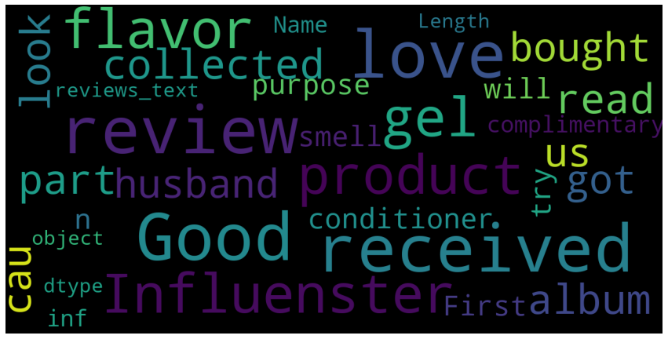

```python
import wordcloud
from wordcloud import WordCloud, STOPWORDS
stopwords = set(STOPWORDS)

def most_commonword(data, title = None):
    wcloud_obj = WordCloud(
        background_color='black',
        stopwords=stopwords,
        max_words=200,
        max_font_size=40,
        scale=3,
        random_state=1
).generate(str(data))

    fig = plt.figure(1, figsize=(15, 15))
    plt.axis('off')
    if title:
        fig.suptitle(title, fontsize=20)
        fig.subplots_adjust(top=2.3)

    plt.imshow(wcloud_obj)
    plt.show()

most_commonword(reviews_df['reviews_text'])
```

- Lets find the ratings distribution

```python
reviews_df['reviews_rating'].value_counts()
```

```
5    20831
4     6020
1     1384
3     1345
2      420
Name: reviews_rating, dtype: int64
```

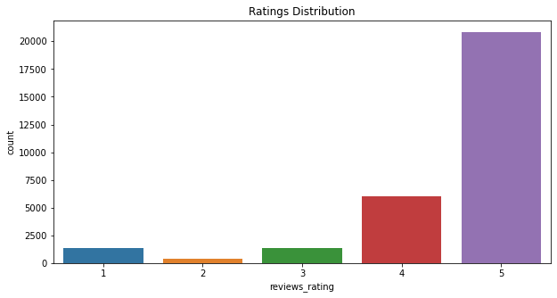

```python
plt.figure(figsize=[10,5])
ax = sns.countplot(x="reviews_rating", data=reviews_df)
plt.title('Ratings Distribution')
```

- Out of all the ratings most people have rated 5 for the products in the dataset
- lets check the how distribution of length of reviews are related to ratings given by users

```python
reviews_df['reviews_len']=reviews_df['reviews_text'].apply(len)
```

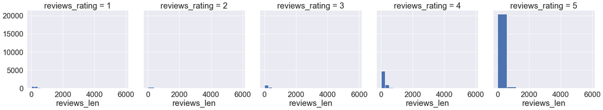

```python
sns.set(font_scale=2.0)
g = sns.FacetGrid(reviews_df,col='reviews_rating',size=5)
g.map(plt.hist,'reviews_len')
#reviews_df.drop(columns='reviews_len',inplace=True)
```

- There are many null values in reviews_didPurchase column lets find many of them are really purchased by filling nan values as null and plot how many of them are genuinely gave reviews

```python
reviews_df['reviews_didPurchase'].fillna("null",inplace=True)
```

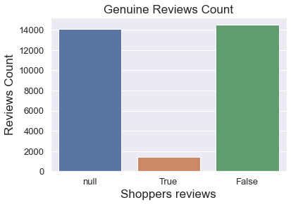

```python
ax = sns.countplot(reviews_df['reviews_didPurchase'])
ax.set_xlabel(xlabel="Shoppers reviews", fontsize=17)
ax.set_ylabel(ylabel='Reviews Count', fontsize=17)
ax.axes.set_title('Genuine Reviews Count', fontsize=17)
ax.tick_params(labelsize=13)
```

```python
reviews_df['reviews_didPurchase'].value_counts(normalize=True)
```

```
False    0.483267
null     0.468933
True     0.047800
Name: reviews_didPurchase, dtype: float64
```

- From the above we can tell that there are very less customer who had purchased and gave reviews

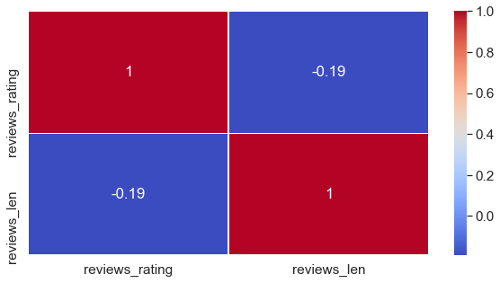

```python
sns.set(font_scale=1.4)
plt.figure(figsize = (10,5))
sns.heatmap(reviews_df.corr(),cmap='coolwarm',annot=True,linewidths=.5)
```

- Lets find which is the top most product purchased from the customers who had purchased

```python
purchased_df = reviews_df[reviews_df['reviews_didPurchase'] == True]
purchased_df['name'].value_counts()
```

```
Hormel Chili, No Beans                                                                                  91
Coty Airspun Face Powder, Translucent Extra Coverage                                                    87
Chester's Cheese Flavored Puffcorn Snacks                                                               77
Tostitos Bite Size Tortilla Chips                                                                       59
Lysol Concentrate Deodorizing Cleaner, Original Scent                                                   55
                                                                                                        ..
Carson-Dellosa Publishing Photographic Learning Cards Boxed Set, Nouns/verbs/adjectives, Grades K-12     1
Bill Glor Gaither - Church In The Wildwood (cd)                                                          1
Sizzix Framelits Dies 1by Tim Holtz Bird Crazy-Silver Asst Sizes                                         1
Queen Helene Cocoa Butter Solid                                                                          1
Head & Shoulders Classic Clean Conditioner                                                               1
Name: name, Length: 144, dtype: int64
```

- Lets find which product has top most ratings given from the purchased customers

```python
max_ratings=purchased_df[purchased_df['reviews_rating'] == 5]
max_ratings['name'].value_counts()
```

```
Coty Airspun Face Powder, Translucent Extra Coverage                                                    74
Chester's Cheese Flavored Puffcorn Snacks                                                               72
Hormel Chili, No Beans                                                                                  55
Lysol Concentrate Deodorizing Cleaner, Original Scent                                                   51
Cheetos Crunchy Flamin' Hot Cheese Flavored Snacks                                                      45
                                                                                                        ..
There's Something About Mary (dvd)                                                                       1
Stacy's Garden Veggie Medley Pita Chips                                                                  1
Black Front Loading Frame Set (8.5x11) Set Of 12                                                         1
Coola Organic Sunscreen Classic Face Cucumber SPF 30                                                     1
Carson-Dellosa Publishing Photographic Learning Cards Boxed Set, Nouns/verbs/adjectives, Grades K-12     1
Name: name, Length: 131, dtype: int64
```

- Plotting the brand distribution of top 10 brands

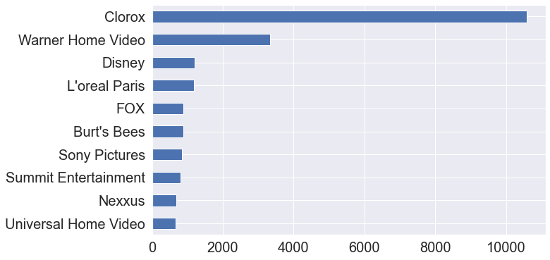

```python
reviews_df['brand'].value_counts()[0:10].plot(kind='barh', figsize=[10,6], fontsize=20).invert_yaxis()
```

- Out of all the columns reviews_text is the important column finding the sentiments of a product so lets do text processing on this column

### Lower case

- Lets convert all the reviews_text into lowercase

```python
reviews_df['reviews_text'] = reviews_df['reviews_text'].apply(lambda x: " ".join(x.lower() for x in x.split()))
reviews_df['reviews_text'].head()
```

```
0    i love this album. it's very good. more to the...
1    good flavor. this review was collected as part...
2                                         good flavor.
3    i read through the reviews on here before look...
4    my husband bought this gel for us. the gel cau...
Name: reviews_text, dtype: object
```

### Punctuation Removal

- Lets remove the punctuation in reviews_text

```python
reviews_df['reviews_text'] = reviews_df['reviews_text'].str.replace('[^\w\s]','')
reviews_df['reviews_text'].head()
```

```
0    i love this album its very good more to the hi...
1    good flavor this review was collected as part ...
2                                          good flavor
3    i read through the reviews on here before look...
4    my husband bought this gel for us the gel caus...
Name: reviews_text, dtype: object
```

```python
##Spell correction is consuming huge time
#from textblob import TextBlob
#reviews_df['r_txts_title'].apply(lambda x: str(TextBlob(x).correct()))
```

### Stopwords Removal

- Lets remove the stopwords from reviews_text column

```python
from nltk.corpus import stopwords
stop_words = stopwords.words('english')
reviews_df['reviews_text'] = reviews_df['reviews_text'].apply(lambda x: " ".join(x for x in x.split() if x not in stop_words))
reviews_df['reviews_text'].head()
```

```
0    love album good hip hop side current pop sound...
1          good flavor review collected part promotion
2                                          good flavor
3    read reviews looking buying one couples lubric...
4    husband bought gel us gel caused irritation fe...
Name: reviews_text, dtype: object
```

### Frequent words Removal

- Finding the most frequent words and removing them

```python
freq_ten = pd.Series(' '.join(reviews_df['reviews_text']).split()).value_counts()[:10]
freq_ten
```

```
review       9113
part         9046
great        8865
promotion    8747
collected    8745
love         8348
use          7946
product      7670
movie        6233
wipes        5204
dtype: int64
```

```python
freq_ten = list(freq_ten.index)
reviews_df['reviews_text'] = reviews_df['reviews_text'].apply(lambda x: " ".join(x for x in x.split() if x not in freq_ten))
reviews_df['reviews_text'].head()
```

```
0    album good hip hop side current pop sound hype...
1                                          good flavor
2                                          good flavor
3    read reviews looking buying one couples lubric...
4    husband bought gel us gel caused irritation fe...
Name: reviews_text, dtype: object
```

### Rare words Removal

- Removing the rare words as they add noise to the data

```python
freq_rare = pd.Series(' '.join(reviews_df['reviews_text']).split()).value_counts()[-10:]
freq_rare
```

```
slimness              1
effectivenessprice    1
67oz                  1
coughcold             1
auditoriums           1
decline               1
seasalt               1
airdrying             1
asain                 1
seafoodthis           1
dtype: int64
```

```python
freq_rare = list(freq_rare.index)
reviews_df['reviews_text'] = reviews_df['reviews_text'].apply(lambda x: " ".join(x for x in x.split() if x not in freq_rare))
reviews_df['reviews_text'].head()
```

```
0    album good hip hop side current pop sound hype...
1                                          good flavor
2                                          good flavor
3    read reviews looking buying one couples lubric...
4    husband bought gel us gel caused irritation fe...
Name: reviews_text, dtype: object
```

### Stemming

- Performing stemming on the reviews_text

```python
from nltk.stem import PorterStemmer
st = PorterStemmer()
reviews_df['reviews_text'].apply(lambda x: " ".join([st.stem(word) for word in x.split()]))
```

```
0        album good hip hop side current pop sound hype...
1                                              good flavor
2                                              good flavor
3        read review look buy one coupl lubric ultim di...
4        husband bought gel us gel caus irrit felt like...
                               ...
29995    got condition influenst tri im love far oili h...
29996    receiv purpos influenst leav hair feel fresh s...
29997    first smell wash hair smooth easi brush receiv...
29998    receiv influenst never go back anyth els norma...
29999    receiv complimentari influenst realli save hai...
Name: reviews_text, Length: 30000, dtype: object
```

### Lemmatization

- Performing lemmatization the texts

```python
from textblob import Word
reviews_df['reviews_text'] = reviews_df['reviews_text'].apply(lambda x: " ".join([Word(word).lemmatize() for word in x.split()]))
reviews_df['reviews_text'].head()
```

```
0    album good hip hop side current pop sound hype...
1                                          good flavor
2                                          good flavor
3    read review looking buying one couple lubrican...
4    husband bought gel u gel caused irritation fel...
Name: reviews_text, dtype: object
```

- Mapping the user_sentiment to binary value i.e; 1 or 0 in which 1 and 0 representive positive and negative respectively

```python
reviews_df['user_sentiment']=reviews_df['user_sentiment'].map({"Positive":1,"Negative":0})
```

- There is one null value so lets drop it

```python
reviews_df = reviews_df.dropna(subset=['user_sentiment'])
df_final=reviews_df.copy()
```

### Train-Test Split

- Performing Train and test split here out of all the columns in a dataframe reviews_text is important and is enough for predicting the user sentiments, so lets consider it for train and test split

```python
X = reviews_df['reviews_text']
y = reviews_df['user_sentiment']
```

```python
import time
from sklearn.metrics import accuracy_score
from sklearn.model_selection import train_test_split
seed = 43

X_train, X_test, y_train, y_test = train_test_split(X, y, test_size=0.2, random_state=seed)
print('X_train', X_train.shape)
print('y_train', y_train.shape)
print('X_test', X_test.shape)
print('y_test', y_test.shape)
```

```
X_train (23999,)
y_train (23999,)
X_test (6000,)
y_test (6000,)
```

```python
y_train.value_counts()
```

```
1.0    21288
0.0     2711
Name: user_sentiment, dtype: int64
```

- There is an imbalance in dataset we will handle them using a parameter in built algorithms and other methods

```python
y_train.unique()
```

```
array([1., 0.])
```

### Feature Extraction

- using TfidfVectorizer
- Lets fit the train texts and transform the test data

```python
tfidf_vect = TfidfVectorizer()
train_tfidf = tfidf_vect.fit_transform(X_train)
test_tfidf=tfidf_vect.transform(X_test)
```

```python
#importing few other statements
from sklearn.linear_model import LogisticRegression
from sklearn.model_selection import KFold, cross_val_score
from sklearn.metrics import accuracy_score
from sklearn.metrics import confusion_matrix, classification_report
from sklearn.model_selection import GridSearchCV,RepeatedStratifiedKFold
from sklearn import metrics
import pickle
```

### Logistic Regression

- As the data is imbalanced so lets use class_weight parameter to make it distributed evenly

```python
LRModel=LogisticRegression(class_weight={0:0.6,1:0.4},random_state=seed)
```

- Creating custom functions as we reutilise them very often

```python
def FitModel(alg, X_train, y_train):
    #Fit the algorithm on the data
    alg.fit(X_train, y_train)

    #Predict training set:
    dtrain_predictions = alg.predict(X_train)
    dtrain_predprob = alg.predict_proba(X_train)[:,1]

    #Print model report:
    print ("\nModel Report")
    print ("Accuracy : %.4g" % metrics.accuracy_score(y_train, dtrain_predictions))
    print ("Recall/Sensitivity : %.4g" % metrics.recall_score(y_train, dtrain_predictions))
```

```python
def GridCV(alg,X_train,y_train):
    solvers = ['newton-cg', 'lbfgs', 'liblinear']
    penalty = ['l1','l2']
    c_values = [100, 10, 1.0, 0.1, 0.01]
    #weights=np.linspace(0.0,0.99,200)
    #class_wt=[{0:x, 1:1.0-x} for x in weights]
    # define grid search
    grid = dict(solver=solvers,penalty=penalty,C=c_values)
    cv = RepeatedStratifiedKFold(n_splits=10, n_repeats=3, random_state=1)
    grid_search = GridSearchCV(estimator=alg, param_grid=grid, n_jobs=-1, cv=cv,error_score=0)
    grid_result = grid_search.fit(X_train, y_train)
    # summarize results
    print("Best: %f using %s" % (grid_result.best_score_, grid_result.best_params_))
    means = grid_result.cv_results_['mean_test_score']
    stds = grid_result.cv_results_['std_test_score']
    params = grid_result.cv_results_['params']
    for mean, stdev, param in zip(means, stds, params):
        print("%f (%f) with: %r" % (mean, stdev, param))
```

```python
def PredictSentimentsWithProbability(model,X,y,prob):
    # Funtion to predict the sentiments using the input probability cut-off
    # Input arguments: model instance, x and y to predict using model and cut-off probability

    # predict
    pred_probs = model.predict_proba(X)[:,1]

    y_df= pd.DataFrame({'sentiments':y, 'sentiments_prob':pred_probs})
    y_df['final_predicted'] = y_df['sentiments_prob'].map( lambda x: 1 if x > prob else 0)
    # Let's see the head
    ModelMetrics(y_df.sentiments,y_df.final_predicted)
    return y_df
```

```python
def ModelMetrics(actual_sentiments=False,pred_sentiments=False):

    confusion = metrics.confusion_matrix(actual_sentiments, pred_sentiments)

    TP = confusion[1,1] # true positive
    TN = confusion[0,0] # true negatives
    FP = confusion[0,1] # false positives
    FN = confusion[1,0] # false negatives

    # Let's see the sensitivity of our logistic regression model
    print('Sensitivity/Recall : {}'.format(TP / float(TP+FN)))
    # Let us calculate specificity
    print('Specificity: {}'.format(TN / float(TN+FP)))
    # Calculate false postive rate - predicting positive when customer is negative
    print('False Positive Rate: {}'.format(FP/ float(TN+FP)))
    # positive predictive value
    print('Positive predictive value: {}'.format(TP / float(TP+FP)))
    # Negative predictive value
    print('Negative Predictive value: {}'.format(TN / float(TN+ FN)))
    # sklearn precision score value
    print('sklearn precision score value: {}'.format(metrics.precision_score(actual_sentiments, pred_sentiments )))
```

```python
def PlotOptimalCutoff(df):
    #Function to find the optimal cutoff for classifing as positive/negative
    # Let's create columns with different probability cutoffs
    numbers = [float(x)/10 for x in range(10)]
    for i in numbers:
        df[i] = df.sentiments_prob.map( lambda x: 1 if x > i else 0)
    #print(df.head())

    # Now let's calculate accuracy sensitivity and specificity for various probability cutoffs.
    cutoff_df = pd.DataFrame( columns = ['prob','accuracy','sensi','speci'])
    from sklearn.metrics import confusion_matrix

    num = [0.0,0.1,0.2,0.3,0.4,0.5,0.6,0.7,0.8,0.9]
    for i in num:
        cm1 = metrics.confusion_matrix(df.sentiments, df[i] )
        total1=sum(sum(cm1))
        accuracy = (cm1[0,0]+cm1[1,1])/total1

        speci = cm1[0,0]/(cm1[0,0]+cm1[0,1])
        sensi = cm1[1,1]/(cm1[1,0]+cm1[1,1])
        cutoff_df.loc[i] =[ i ,accuracy,sensi,speci]
    print(cutoff_df)
    # Let's plot accuracy sensitivity and specificity for various probabilities.
    cutoff_df.plot.line(x='prob', y=['accuracy','sensi','speci'])
    plt.show()
```

```python
def PlotROC( actual, probs ):
    fpr, tpr, thresholds = metrics.roc_curve( actual, probs)

    auc_score = metrics.auc( fpr,tpr)
    plt.figure(figsize=(6, 6))
    plt.plot( fpr, tpr, label='ROC curve (area = %0.2f)' % auc_score )
    plt.plot([0, 1], [0, 1], 'k--')
    plt.xlim([0.0, 1.0])
    plt.ylim([0.0, 1.05])
    plt.xlabel('False Positive Rate or [1 - True Negative Rate]')
    plt.ylabel('True Positive Rate')
    plt.title('Receiver operating characteristic example')
    plt.legend(loc="lower right")
    plt.show()

    return fpr, tpr, thresholds
```

### Hyperparameter tuning

- Finding out the best parameter to produce an LR Model

```python
GridCV(LRModel,train_tfidf,y_train)
```

```
Best: 0.910441 using {'C': 10, 'penalty': 'l2', 'solver': 'newton-cg'}
0.000000 (0.000000) with: {'C': 100, 'penalty': 'l1', 'solver': 'newton-cg'}
0.000000 (0.000000) with: {'C': 100, 'penalty': 'l1', 'solver': 'lbfgs'}
0.892857 (0.005897) with: {'C': 100, 'penalty': 'l1', 'solver': 'liblinear'}
0.904718 (0.005025) with: {'C': 100, 'penalty': 'l2', 'solver': 'newton-cg'}
0.905135 (0.005027) with: {'C': 100, 'penalty': 'l2', 'solver': 'lbfgs'}
0.904718 (0.004998) with: {'C': 100, 'penalty': 'l2', 'solver': 'liblinear'}
0.000000 (0.000000) with: {'C': 10, 'penalty': 'l1', 'solver': 'newton-cg'}
0.000000 (0.000000) with: {'C': 10, 'penalty': 'l1', 'solver': 'lbfgs'}
0.910107 (0.004427) with: {'C': 10, 'penalty': 'l1', 'solver': 'liblinear'}
0.910441 (0.004546) with: {'C': 10, 'penalty': 'l2', 'solver': 'newton-cg'}
0.910399 (0.004443) with: {'C': 10, 'penalty': 'l2', 'solver': 'lbfgs'}
0.910441 (0.004546) with: {'C': 10, 'penalty': 'l2', 'solver': 'liblinear'}
0.000000 (0.000000) with: {'C': 1.0, 'penalty': 'l1', 'solver': 'newton-cg'}
0.000000 (0.000000) with: {'C': 1.0, 'penalty': 'l1', 'solver': 'lbfgs'}
0.905774 (0.003403) with: {'C': 1.0, 'penalty': 'l1', 'solver': 'liblinear'}
0.899871 (0.002486) with: {'C': 1.0, 'penalty': 'l2', 'solver': 'newton-cg'}
0.899871 (0.002486) with: {'C': 1.0, 'penalty': 'l2', 'solver': 'lbfgs'}
0.899913 (0.002510) with: {'C': 1.0, 'penalty': 'l2', 'solver': 'liblinear'}
0.000000 (0.000000) with: {'C': 0.1, 'penalty': 'l1', 'solver': 'newton-cg'}
0.000000 (0.000000) with: {'C': 0.1, 'penalty': 'l1', 'solver': 'lbfgs'}
0.887009 (0.000242) with: {'C': 0.1, 'penalty': 'l1', 'solver': 'liblinear'}
0.887120 (0.000198) with: {'C': 0.1, 'penalty': 'l2', 'solver': 'newton-cg'}
0.887120 (0.000198) with: {'C': 0.1, 'penalty': 'l2', 'solver': 'lbfgs'}
0.887120 (0.000198) with: {'C': 0.1, 'penalty': 'l2', 'solver': 'liblinear'}
0.000000 (0.000000) with: {'C': 0.01, 'penalty': 'l1', 'solver': 'newton-cg'}
0.000000 (0.000000) with: {'C': 0.01, 'penalty': 'l1', 'solver': 'lbfgs'}
0.887037 (0.000124) with: {'C': 0.01, 'penalty': 'l1', 'solver': 'liblinear'}
0.887037 (0.000124) with: {'C': 0.01, 'penalty': 'l2', 'solver': 'newton-cg'}
0.887037 (0.000124) with: {'C': 0.01, 'penalty': 'l2', 'solver': 'lbfgs'}
0.887037 (0.000124) with: {'C': 0.01, 'penalty': 'l2', 'solver': 'liblinear'}
```

- From above C=10 and penalty='l2' are the best as solver changes for every run so lets build model by using them

```python
LRModel2=LogisticRegression(C=10,class_weight={0:0.6,1:0.4},penalty='l2',random_state=seed)
```

- Fitting the model and finding the model metrics for train data

```python
FitModel(LRModel2,train_tfidf,y_train)
y_pred_train=LRModel2.predict(train_tfidf)
ModelMetrics(y_train,y_pred_train)
```

```
Model Report
Accuracy : 0.9612
Recall/Sensitivity : 0.989
Sensitivity/Recall : 0.9890078917700112
Specificity: 0.7425304315750646
False Positive Rate: 0.25746956842493546
Positive predictive value: 0.9679109966899595
Negative Predictive value: 0.8958611481975968
sklearn precision score value: 0.9679109966899595
```

- predictions on Test data

```python
# predictions on Test data
y_pred_test=LRModel2.predict(test_tfidf)
ModelMetrics(y_test,y_pred_test)
```

```
Sensitivity/Recall : 0.9758607784431138
Specificity: 0.4451219512195122
False Positive Rate: 0.5548780487804879
Positive predictive value: 0.9347553324968633
Negative Predictive value: 0.6935866983372921
sklearn precision score value: 0.9347553324968633
```

```python
print("Accuracy for test  : {}".format(metrics.accuracy_score(y_test,y_pred_test)))
print("Recall for test: {}".format(metrics.recall_score(y_test,y_pred_test)))
print("Precision for test : {}".format(metrics.precision_score(y_test,y_pred_test)))
```

```
Accuracy for test  : 0.9178333333333333
Recall for test: 0.9758607784431138
Precision for test : 0.9347553324968633
```

```python
y_train_proba=LRModel2.predict_proba(train_tfidf)[:,1]
fpr,tpr,thresholds=metrics.roc_curve(y_train,y_train_proba)
print("AUC for train" , metrics.auc(fpr,tpr))
```

```
AUC for train 0.9834292808357561
```

- setting 0.5 as cutoff

```python
cut_off_prob=0.5
y_train_df = PredictSentimentsWithProbability(LRModel2,train_tfidf,y_train,cut_off_prob)
y_train_df.head()
```

```
Sensitivity/Recall : 0.9890078917700112
Specificity: 0.7425304315750646
False Positive Rate: 0.25746956842493546
Positive predictive value: 0.9679109966899595
Negative Predictive value: 0.8958611481975968
sklearn precision score value: 0.9679109966899595
```

|  | sentiments | sentiments_prob | final_predicted |
| --- | --- | --- | --- |
| 2602 | 1.0 | 0.999184 | 1 |
| 4212 | 1.0 | 0.970523 | 1 |
| 3819 | 0.0 | 0.472990 | 0 |
| 8805 | 1.0 | 0.999958 | 1 |
| 19952 | 1.0 | 0.989592 | 1 |

- plotting ROC Curve

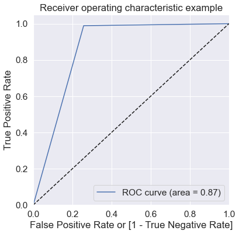

```
(array([0.        , 0.25746957, 1.        ]),
 array([0.        , 0.98900789, 1.        ]),
 array([2, 1, 0], dtype=int64))
```

```python
PlotROC(y_train_df.sentiments, y_train_df.final_predicted)
```

- Finding Optimal Cutoff Point
- Finding cut-off with the right balance of the metrices
- sensitivity vs specificity trade-off

```
     prob  accuracy     sensi     speci
0.0   0.0  0.887037  1.000000  0.000000
0.1   0.1  0.895621  0.999342  0.081151
0.2   0.2  0.909580  0.998638  0.210255
0.3   0.3  0.926122  0.997228  0.367761
0.4   0.4  0.947373  0.994363  0.578384
0.5   0.5  0.961165  0.989008  0.742530
0.6   0.6  0.963248  0.976700  0.857617
0.7   0.7  0.945998  0.947482  0.934342
0.8   0.8  0.901371  0.892522  0.970859
0.9   0.9  0.789491  0.763998  0.989672
```

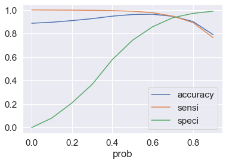

```python
PlotOptimalCutoff(y_train_df)
```

- here around 0.7 is the optimal cutoff as we are concerned about making positives so lets consider 0.75

```python
cut_off_prob = 0.75
y_train_df=PredictSentimentsWithProbability(LRModel2,train_tfidf,y_train,cut_off_prob)
y_train_df
```

```
Sensitivity/Recall : 0.9268602029312288
Specificity: 0.9568424935448174
False Positive Rate: 0.04315750645518259
Positive predictive value: 0.994105199516324
Negative Predictive value: 0.6249096603228138
sklearn precision score value: 0.994105199516324
```

|  | sentiments | sentiments_prob | final_predicted |
| --- | --- | --- | --- |
| 2602 | 1.0 | 0.999184 | 1 |
| 4212 | 1.0 | 0.970523 | 1 |
| 3819 | 0.0 | 0.472990 | 0 |
| 8805 | 1.0 | 0.999958 | 1 |
| 19952 | 1.0 | 0.989592 | 1 |
| ... | ... | ... | ... |
| 26901 | 1.0 | 0.808041 | 1 |
| 7985 | 1.0 | 0.989314 | 1 |
| 18687 | 1.0 | 0.565851 | 0 |
| 19776 | 0.0 | 0.472591 | 0 |
| 14148 | 1.0 | 0.604779 | 0 |

23999 rows × 3 columns

```python
# for test
y_test_df=PredictSentimentsWithProbability(LRModel2,test_tfidf,y_test,cut_off_prob)
y_test_df
```

```
Sensitivity/Recall : 0.8929640718562875
Specificity: 0.7576219512195121
False Positive Rate: 0.2423780487804878
Positive predictive value: 0.967755019265869
Negative Predictive value: 0.46492048643592143
sklearn precision score value: 0.967755019265869
```

|  | sentiments | sentiments_prob | final_predicted |
| --- | --- | --- | --- |
| 17173 | 1.0 | 0.977370 | 1 |
| 28361 | 1.0 | 0.946644 | 1 |
| 18990 | 1.0 | 0.850405 | 1 |
| 1948 | 1.0 | 0.907333 | 1 |
| 10283 | 1.0 | 0.795708 | 1 |
| ... | ... | ... | ... |
| 15439 | 1.0 | 0.619523 | 0 |
| 8578 | 1.0 | 0.991801 | 1 |
| 19714 | 1.0 | 0.995975 | 1 |
| 5865 | 1.0 | 0.995576 | 1 |
| 669 | 1.0 | 0.964687 | 1 |

6000 rows × 3 columns

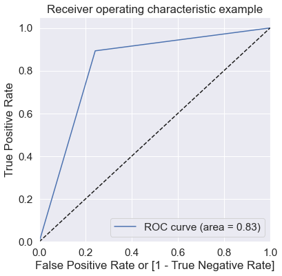

```
(array([0.        , 0.24237805, 1.        ]),
 array([0.        , 0.89296407, 1.        ]),
 array([2, 1, 0], dtype=int64))
```

```python
PlotROC(y_test_df.sentiments,y_test_df.final_predicted)
```

- The overall comparision for Train and test AUC curves

```
AUC for train 0.9834292808357561
AUC for test 0.9289923392544179
```

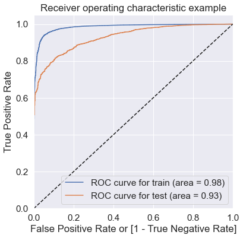

```python
y_train_proba=LRModel2.predict_proba(train_tfidf)[:,1]
y_test_proba=LRModel2.predict_proba(test_tfidf)[:,1]
fpr,tpr,thresholds=metrics.roc_curve(y_train,y_train_proba)
fpr1,tpr1,thresholds1=metrics.roc_curve(y_test,y_test_proba)
print("AUC for train" , metrics.auc(fpr,tpr))
print("AUC for test" , metrics.auc(fpr1,tpr1))
plt.figure(figsize=(6, 6))
plt.plot( fpr, tpr, label='ROC curve for train (area = %0.2f)' % metrics.auc(fpr,tpr ))
plt.plot( fpr1, tpr1, label='ROC curve for test (area = %0.2f)' % metrics.auc(fpr1,tpr1) )
plt.plot([0, 1], [0, 1], 'k--')
plt.xlim([0.0, 1.0])
plt.ylim([0.0, 1.05])
plt.xlabel('False Positive Rate or [1 - True Negative Rate]')
plt.ylabel('True Positive Rate')
plt.title('Receiver operating characteristic example')
plt.legend(loc="lower right")
plt.show()
```

```python
# Save the model
import joblib
# Save the model as a pickle in a file
joblib.dump(LRModel2, 'LRModel.pkl')
```

```
['LRModel.pkl']
```

```python
df_final.to_csv("processed_txts.csv")
#Save the vectorizer
joblib.dump(tfidf_vect,"tfidf_vect.pkl")
```

```
['tfidf_vect.pkl']
```

- Sensitivity for train 0.92, train_auc= 0.98
- Sensitivity for test 0.89, test auc = 0.92

### RandomForest

- As there are no inbuilt models for this algorithm for balancing so lets balance the dataset by using SMOTE

```python
print("Before OverSampling, counts of label '1': {}".format(sum(y_train==1)))
print("Before OverSampling, counts of label '0': {} \n".format(sum(y_train==0)))
print("Before OverSampling, sentiments rate : {}% \n".format(round(sum(y_train==1)/len(y_train)*100,2)))
```

```
Before OverSampling, counts of label '1': 21288
Before OverSampling, counts of label '0': 2711

Before OverSampling, sentiments rate : 88.7%
```

```python
from imblearn.over_sampling import SMOTE
sm = SMOTE(random_state=seed)
X_train_smote, y_train_smote = sm.fit_sample(train_tfidf, y_train)
```

```python
print('After OverSampling, the shape of train_X: {}'.format(X_train_smote.shape))
print('After OverSampling, the shape of train_y: {} \n'.format(y_train_smote.shape))

print("After OverSampling, counts of label '1': {}".format(sum(y_train_smote==1)))
print("After OverSampling, counts of label '0': {}".format(sum(y_train_smote==0)))
print("After OverSampling, sentiments event rate : {}% \n".format(round(sum(y_train_smote==1)/len(y_train_smote)*100,2)))
```

```
After OverSampling, the shape of train_X: (42576, 16971)
After OverSampling, the shape of train_y: (42576,)

After OverSampling, counts of label '1': 21288
After OverSampling, counts of label '0': 21288
After OverSampling, sentiments event rate : 50.0%
```

- Now the dataset is balanced so lets perform hyper parameter tuning

### Hyperparameter Tuning

```python
from sklearn.model_selection import RandomizedSearchCV
from sklearn.ensemble import RandomForestClassifier

parameters = {'max_depth': range(10, 30, 5)}
RFModel = RandomForestClassifier()
Kfold=5
rf_gs = RandomizedSearchCV(RFModel, parameters, cv=Kfold,scoring="f1", return_train_score=True,random_state=seed)
rf_gs.fit(train_tfidf,y_train)
```

```
RandomizedSearchCV(cv=5, estimator=RandomForestClassifier(),
                   param_distributions={'max_depth': range(10, 30, 5)},
                   random_state=43, return_train_score=True, scoring='f1')
```

- Tuning max_depth
- plotting accuracies with max_depth

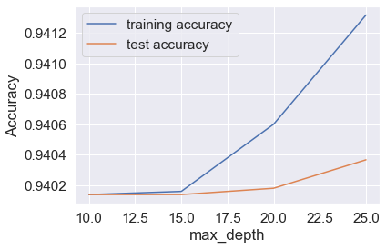

```python
scores = rf_gs.cv_results_
plt.figure()
plt.plot(scores["param_max_depth"],
         scores["mean_train_score"],
         label="training accuracy")
plt.plot(scores["param_max_depth"],
         scores["mean_test_score"],
         label="test accuracy")
plt.xlabel("max_depth")
plt.ylabel("Accuracy")
plt.legend()
plt.show()
```

```python
parameters = {'n_estimators': range(50, 150, 25)}
rf1 = RandomForestClassifier(max_depth=10,random_state=seed)
rf_gs = RandomizedSearchCV(rf1, parameters,
                    cv=Kfold,
                   scoring="recall", return_train_score=True)
```

```python
rf_gs.fit(X_train_smote,y_train_smote)
```

```
RandomizedSearchCV(cv=5,
                   estimator=RandomForestClassifier(max_depth=10,
                                                    random_state=43),
                   param_distributions={'n_estimators': range(50, 150, 25)},
                   return_train_score=True, scoring='recall')
```

- plotting accuracies

```python
def PlotTrainTestAcc(score,param):
    scores = score
    plt.figure()
    plt.plot(scores["param_"+param],
    scores["mean_train_score"],
    label="training accuracy")
    plt.plot(scores["param_"+param],
    scores["mean_test_score"],
    label="test accuracy")
    plt.xlabel(param)
    plt.ylabel("f1")
    plt.legend()
    plt.show()
```

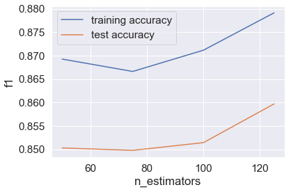

```python
PlotTrainTestAcc(rf_gs.cv_results_,'n_estimators')
```

```python
parameters = {'max_features': [4, 8, 14, 20, 24]}
rf3 = RandomForestClassifier(max_depth=10,n_estimators=100,random_state=seed)
rf_gs = RandomizedSearchCV(rf3, parameters,
                    cv=Kfold,
                   scoring="f1", return_train_score=True)
```

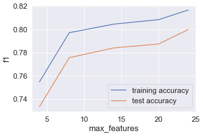

```python
rf_gs.fit(X_train_smote,y_train_smote)
PlotTrainTestAcc(rf_gs.cv_results_,'max_features')
```

```python
parameters = {'min_samples_leaf': range(100, 400, 50)}
rf4 = RandomForestClassifier(max_depth=10,n_estimators=100,max_features=8,random_state=seed)
rf_gs = RandomizedSearchCV(rf4, parameters,
                    cv=Kfold,
                   scoring="f1", return_train_score=True)
```

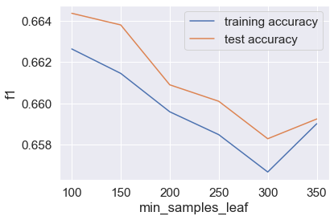

```python
rf_gs.fit(X_train_smote,y_train_smote)
PlotTrainTestAcc(rf_gs.cv_results_,'min_samples_leaf')
```

```python
parameters = {'min_samples_split': range(50, 300, 50)}
rf5 = RandomForestClassifier(max_depth=10,n_estimators=100,max_features=8,min_samples_leaf=150,random_state=seed)
rf_gs = RandomizedSearchCV(rf5, parameters,
                    cv=Kfold,
                   scoring="f1", return_train_score=True)
```

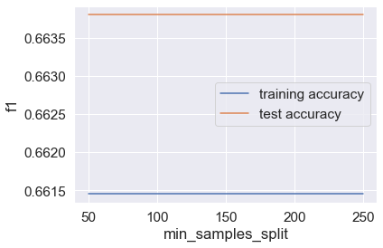

```python
rf_gs.fit(X_train_smote,y_train_smote)
PlotTrainTestAcc(rf_gs.cv_results_,'min_samples_split')
```

- optimal min_samples_split=50
- Tuning Randaom Forest model with obtained optimal parameters

```python
rf_final = RandomForestClassifier(max_depth=10,
                                  n_estimators=100,
                                  max_features=8,
                                  min_samples_leaf=150,
                                  min_samples_split=50,
                                  random_state=seed)
```

```python
print("Model performance on Train data:")
FitModel(rf_final,X_train_smote,y_train_smote)
```

```
Model performance on Train data:

Model Report
Accuracy : 0.5955
Recall/Sensitivity : 0.7999
```

- predict on test data

```python
dt_test_pred = rf_final.predict(test_tfidf)
dt_train_pred= rf_final.predict(X_train_smote)
```

```python
print("Model performance on Test data:")
ModelMetrics(y_test,dt_test_pred)
```

```
Model performance on Test data:
Sensitivity/Recall : 0.8025823353293413
Specificity: 0.2728658536585366
False Positive Rate: 0.7271341463414634
Positive predictive value: 0.899916072177927
Negative Predictive value: 0.14505672609400325
sklearn precision score value: 0.899916072177927
```

```python
# predicting churn with default cut-off 0.5
cut_off_prob=0.5
y_train_df = PredictSentimentsWithProbability(rf_final,X_train_smote,y_train_smote,cut_off_prob)
y_train_df.head()
```

```
Sensitivity/Recall : 0.7998872604284104
Specificity: 0.391065388951522
False Positive Rate: 0.608934611048478
Positive predictive value: 0.5677703310993298
Negative Predictive value: 0.6615017878426699
sklearn precision score value: 0.5677703310993298
```

|  | sentiments | sentiments_prob | final_predicted |
| --- | --- | --- | --- |
| 0 | 1.0 | 0.500245 | 1 |
| 1 | 1.0 | 0.500245 | 1 |
| 2 | 0.0 | 0.500245 | 1 |
| 3 | 1.0 | 0.500245 | 1 |
| 4 | 1.0 | 0.498319 | 0 |

```
     prob  accuracy     sensi     speci
0.0   0.0  0.500000  1.000000  0.000000
0.1   0.1  0.500000  1.000000  0.000000
0.2   0.2  0.500000  1.000000  0.000000
0.3   0.3  0.500000  1.000000  0.000000
0.4   0.4  0.500000  1.000000  0.000000
0.5   0.5  0.595476  0.799887  0.391065
0.6   0.6  0.500000  0.000000  1.000000
0.7   0.7  0.500000  0.000000  1.000000
0.8   0.8  0.500000  0.000000  1.000000
0.9   0.9  0.500000  0.000000  1.000000
```

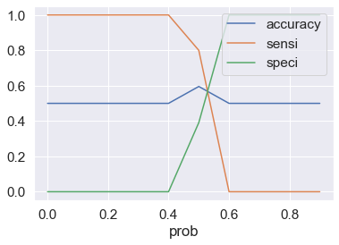

```python
# finding cut-off with the right balance of the metrices
PlotOptimalCutoff(y_train_df)
```

```python
cut_off_prob=0.55
PredictSentimentsWithProbability(rf_final,X_train_smote,y_train_smote,cut_off_prob)
```

```
Sensitivity/Recall : 0.0
Specificity: 1.0
False Positive Rate: 0.0
Positive predictive value: nan
Negative Predictive value: 0.5
sklearn precision score value: 0.0
```

|  | sentiments | sentiments_prob | final_predicted |
| --- | --- | --- | --- |
| 0 | 1.0 | 0.500245 | 0 |
| 1 | 1.0 | 0.500245 | 0 |
| 2 | 0.0 | 0.500245 | 0 |
| 3 | 1.0 | 0.500245 | 0 |
| 4 | 1.0 | 0.498319 | 0 |
| ... | ... | ... | ... |
| 42571 | 0.0 | 0.500245 | 0 |
| 42572 | 0.0 | 0.500245 | 0 |
| 42573 | 0.0 | 0.500245 | 0 |
| 42574 | 0.0 | 0.499158 | 0 |
| 42575 | 0.0 | 0.499158 | 0 |

42576 rows × 3 columns

```python
y_test_df=PredictSentimentsWithProbability(rf_final,test_tfidf,y_test,cut_off_prob)
y_test_df.head()
```

```
Sensitivity/Recall : 0.0
Specificity: 1.0
False Positive Rate: 0.0
Positive predictive value: nan
Negative Predictive value: 0.10933333333333334
sklearn precision score value: 0.0
```

|  | sentiments | sentiments_prob | final_predicted |
| --- | --- | --- | --- |
| 17173 | 1.0 | 0.497771 | 0 |
| 28361 | 1.0 | 0.498961 | 0 |
| 18990 | 1.0 | 0.500245 | 0 |
| 1948 | 1.0 | 0.500245 | 0 |
| 10283 | 1.0 | 0.501388 | 0 |

```python
print("Accuracy for test : {}".format(metrics.accuracy_score(y_test,dt_test_pred)))
print("Recall for test : {}".format(metrics.recall_score(y_test,dt_test_pred)))
print("Precision for test: {}".format(metrics.precision_score(y_test,dt_test_pred)))
```

```
Accuracy for test : 0.7446666666666667
Recall for test : 0.8025823353293413
Precision for test: 0.899916072177927
```

```
AUC for train 0.5815688925003996
AUC for test 0.5739564601741637
```

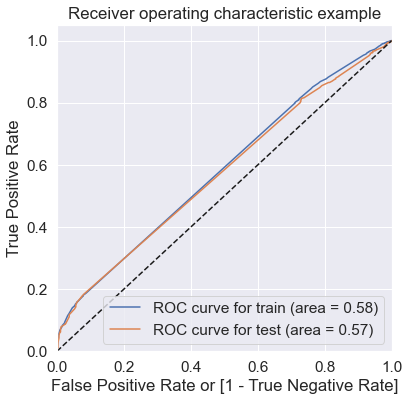

```python
rf_train_proba=rf_final.predict_proba(train_tfidf)[:,1]
rf_test_proba=rf_final.predict_proba(test_tfidf)[:,1]
fpr,tpr,thresholds=metrics.roc_curve(y_train,rf_train_proba)
fpr1,tpr1,thresholds1=metrics.roc_curve(y_test,rf_test_proba)
print("AUC for train" , metrics.auc(fpr,tpr))
print("AUC for test" , metrics.auc(fpr1,tpr1))
plt.figure(figsize=(6, 6))
plt.plot( fpr, tpr, label='ROC curve for train (area = %0.2f)' % metrics.auc(fpr,tpr ))
plt.plot( fpr1, tpr1, label='ROC curve for test (area = %0.2f)' % metrics.auc(fpr1,tpr1) )
plt.plot([0, 1], [0, 1], 'k--')
plt.xlim([0.0, 1.0])
plt.ylim([0.0, 1.05])
plt.xlabel('False Positive Rate or [1 - True Negative Rate]')
plt.ylabel('True Positive Rate')
plt.title('Receiver operating characteristic example')
plt.legend(loc="lower right")
plt.show()
```

- RF Model performs poorly

### Boosting Models

- GradientBoostClassifier
- xgboost ### Gradient Boosting

```python
from sklearn.ensemble import GradientBoostingClassifier
# Lets Fit the default GradientBoostingClassifier
GBCModel = GradientBoostingClassifier(random_state=seed)
FitModel(GBCModel, X_train_smote, y_train_smote)
```

```
Model Report
Accuracy : 0.8333
Recall/Sensitivity : 0.7161
```

### Hyperparameter tuning for n_estimators

```python
param_test1 = {'n_estimators':range(20,150,10)}
gsearch1 = GridSearchCV(estimator = GradientBoostingClassifier(learning_rate=0.1, min_samples_split=500,min_samples_leaf=50,max_depth=8,max_features='sqrt',subsample=0.8,random_state=seed),
param_grid = param_test1, scoring='f1',n_jobs=4,iid=False, cv=Kfold)
gsearch1.fit(X_train_smote, y_train_smote)
```

```
GridSearchCV(cv=5,
             estimator=GradientBoostingClassifier(max_depth=8,
                                                  max_features='sqrt',
                                                  min_samples_leaf=50,
                                                  min_samples_split=500,
                                                  random_state=43,
                                                  subsample=0.8),
             iid=False, n_jobs=4,
             param_grid={'n_estimators': range(20, 150, 10)}, scoring='f1')
```

```python
gsearch1.best_params_, gsearch1.best_score_
```

```
({'n_estimators': 140}, 0.8599531053939925)
```

### Hyperparameter tuning for max_depth and min_sample_split

```python
param_test2 = {'max_depth':range(5,16,2), 'min_samples_split':range(200,1001,200)}
gsearch2 = GridSearchCV(estimator = GradientBoostingClassifier(learning_rate=0.1, n_estimators=140, max_features='sqrt', subsample=0.8, random_state=seed),
param_grid = param_test2, scoring='f1',n_jobs=4,iid=False, cv=Kfold)
gsearch2.fit(X_train_smote, y_train_smote)
```

```
GridSearchCV(cv=5,
             estimator=GradientBoostingClassifier(max_features='sqrt',
                                                  n_estimators=140,
                                                  random_state=43,
                                                  subsample=0.8),
             iid=False, n_jobs=4,
             param_grid={'max_depth': range(5, 16, 2),
                         'min_samples_split': range(200, 1001, 200)},
             scoring='f1')
```

```python
gsearch2.best_params_, gsearch2.best_score_
```

```
({'max_depth': 15, 'min_samples_split': 200}, 0.9044096695792427)
```

### Hyperparameter tuning for min_sample_leaf

```python
param_test3 = {'min_samples_leaf':range(30,71,10)}
gsearch3 = GridSearchCV(estimator = GradientBoostingClassifier(learning_rate=0.1, n_estimators=140,max_depth=15,min_samples_split=200, max_features='sqrt', subsample=0.8, random_state=seed),
param_grid = param_test3, scoring='f1',n_jobs=4,iid=False, cv=Kfold)
gsearch3.fit(X_train_smote, y_train_smote)
```

```
GridSearchCV(cv=5,
             estimator=GradientBoostingClassifier(max_depth=15,
                                                  max_features='sqrt',
                                                  min_samples_split=200,
                                                  n_estimators=140,
                                                  random_state=43,
                                                  subsample=0.8),
             iid=False, n_jobs=4,
             param_grid={'min_samples_leaf': range(30, 71, 10)}, scoring='f1')
```

```python
gsearch3.best_params_, gsearch3.best_score_
```

```
({'min_samples_leaf': 30}, 0.8839411940015243)
```

### Hyperparameter tuning for max_features

```python
param_test4 = {'max_features':range(7,20,2)}
gsearch4 = GridSearchCV(estimator = GradientBoostingClassifier(learning_rate=0.1, n_estimators=140,max_depth=15, min_samples_split=200, min_samples_leaf=30, subsample=0.8, random_state=seed),
param_grid = param_test4, scoring='f1',n_jobs=4,iid=False, cv=Kfold)
gsearch4.fit(X_train_smote, y_train_smote)
```

```
GridSearchCV(cv=5,
             estimator=GradientBoostingClassifier(max_depth=15,
                                                  min_samples_leaf=30,
                                                  min_samples_split=200,
                                                  n_estimators=140,
                                                  random_state=43,
                                                  subsample=0.8),
             iid=False, n_jobs=4, param_grid={'max_features': range(7, 20, 2)},
             scoring='f1')
```

```python
gsearch4.best_params_, gsearch4.best_score_
```

```
({'max_features': 19}, 0.7960977008000556)
```

```python
# Tuning final GradientBoostingClassifier
gbm_final = GradientBoostingClassifier(learning_rate=0.1, n_estimators=140,max_features=19,max_depth=15, min_samples_split=200, min_samples_leaf=30, subsample=0.8, random_state=seed)
FitModel(gbm_final, X_train_smote, y_train_smote)
```

```
Model Report
Accuracy : 0.8195
Recall/Sensitivity : 0.8418
```

```python
# predictions on Test data
dtest_predictions = gbm_final.predict(test_tfidf)
```

```python
# model Performance on test data
ModelMetrics(y_test,dtest_predictions)
```

```
Sensitivity/Recall : 0.8452470059880239
Specificity: 0.5701219512195121
False Positive Rate: 0.4298780487804878
Positive predictive value: 0.9412377578662221
Negative Predictive value: 0.31140716069941715
sklearn precision score value: 0.9412377578662221
```

```python
# predicting churn with default cut-off 0.5
cut_off_prob=0.5
y_train_df = PredictSentimentsWithProbability(gbm_final,X_train_smote,y_train_smote,cut_off_prob)
y_train_df.head()
```

```
Sensitivity/Recall : 0.8417888012025554
Specificity: 0.7972566704246524
False Positive Rate: 0.2027433295753476
Positive predictive value: 0.8059003417880913
Negative Predictive value: 0.8344149459193707
sklearn precision score value: 0.8059003417880913
```

|  | sentiments | sentiments_prob | final_predicted |
| --- | --- | --- | --- |
| 0 | 1.0 | 0.623239 | 1 |
| 1 | 1.0 | 0.637469 | 1 |
| 2 | 0.0 | 0.468720 | 0 |
| 3 | 1.0 | 0.715674 | 1 |
| 4 | 1.0 | 0.640239 | 1 |

```
     prob  accuracy     sensi     speci
0.0   0.0  0.500000  1.000000  0.000000
0.1   0.1  0.505473  1.000000  0.010945
0.2   0.2  0.526964  0.998826  0.055101
0.3   0.3  0.567738  0.992390  0.143085
0.4   0.4  0.663284  0.969889  0.356680
0.5   0.5  0.819523  0.841789  0.797257
0.6   0.6  0.706572  0.425686  0.987458
0.7   0.7  0.558155  0.116779  0.999530
0.8   0.8  0.506506  0.013012  1.000000
0.9   0.9  0.500164  0.000329  1.000000
```

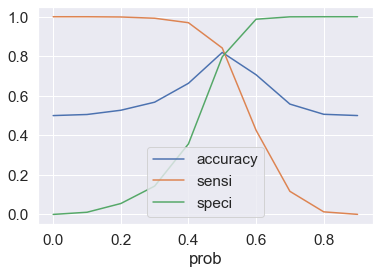

```python
PlotOptimalCutoff(y_train_df)
```

```python
cut_off_prob=0.5
PredictSentimentsWithProbability(gbm_final,X_train_smote,y_train_smote,cut_off_prob)
```

```
Sensitivity/Recall : 0.8417888012025554
Specificity: 0.7972566704246524
False Positive Rate: 0.2027433295753476
Positive predictive value: 0.8059003417880913
Negative Predictive value: 0.8344149459193707
sklearn precision score value: 0.8059003417880913
```

|  | sentiments | sentiments_prob | final_predicted |
| --- | --- | --- | --- |
| 0 | 1.0 | 0.623239 | 1 |
| 1 | 1.0 | 0.637469 | 1 |
| 2 | 0.0 | 0.468720 | 0 |
| 3 | 1.0 | 0.715674 | 1 |
| 4 | 1.0 | 0.640239 | 1 |
| ... | ... | ... | ... |
| 42571 | 0.0 | 0.404918 | 0 |
| 42572 | 0.0 | 0.367930 | 0 |
| 42573 | 0.0 | 0.504754 | 1 |
| 42574 | 0.0 | 0.202124 | 0 |
| 42575 | 0.0 | 0.208045 | 0 |

42576 rows × 3 columns

```python
y_test_df= PredictSentimentsWithProbability(gbm_final,test_tfidf,y_test,cut_off_prob)
y_test_df.head()
```

```
Sensitivity/Recall : 0.8452470059880239
Specificity: 0.5701219512195121
False Positive Rate: 0.4298780487804878
Positive predictive value: 0.9412377578662221
Negative Predictive value: 0.31140716069941715
sklearn precision score value: 0.9412377578662221
```

|  | sentiments | sentiments_prob | final_predicted |
| --- | --- | --- | --- |
| 17173 | 1.0 | 0.567772 | 1 |
| 28361 | 1.0 | 0.558246 | 1 |
| 18990 | 1.0 | 0.533406 | 1 |
| 1948 | 1.0 | 0.510005 | 1 |
| 10283 | 1.0 | 0.515213 | 1 |

```
AUC for train 0.8498893847785083
AUC for test 0.8035239543778298
```

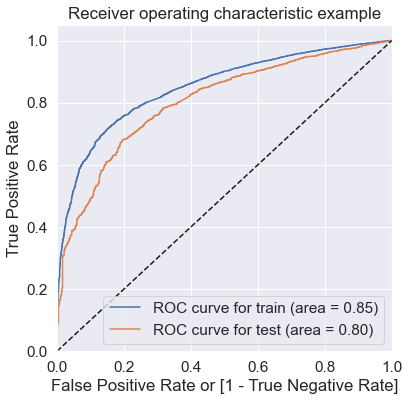

```python
gbm_train_proba=gbm_final.predict_proba(train_tfidf)[:,1]
gbm_test_proba=gbm_final.predict_proba(test_tfidf)[:,1]
fpr,tpr,thresholds=metrics.roc_curve(y_train,gbm_train_proba)
fpr1,tpr1,thresholds1=metrics.roc_curve(y_test,gbm_test_proba)
print("AUC for train" , metrics.auc(fpr,tpr))
print("AUC for test" , metrics.auc(fpr1,tpr1))
plt.figure(figsize=(6, 6))
plt.plot( fpr, tpr, label='ROC curve for train (area = %0.2f)' % metrics.auc(fpr,tpr ))
plt.plot( fpr1, tpr1, label='ROC curve for test (area = %0.2f)' % metrics.auc(fpr1,tpr1) )
plt.plot([0, 1], [0, 1], 'k--')
plt.xlim([0.0, 1.0])
plt.ylim([0.0, 1.05])
plt.xlabel('False Positive Rate or [1 - True Negative Rate]')
plt.ylabel('True Positive Rate')
plt.title('Receiver operating characteristic example')
plt.legend(loc="lower right")
plt.show()
```

- train sensitivity 0.84 auc 0.85
- test sensitivity 0.84 auc 0.80

#### XGBOOSTCLASSIFIER

```python
import xgboost as xgb
from xgboost.sklearn import XGBClassifier
# Fitting the XGBClassifier
xgb1 = XGBClassifier(learning_rate =0.1,
                    n_estimators=1000,
                    max_depth=5,
                    min_child_weight=1,
                    gamma=0,
                    subsample=0.8,
                    colsample_bytree=0.8,
                    objective= 'binary:logistic',
                    nthread=4,
                    #scale_pos_weight=1,
                    seed=seed)
```

- fitting model

```python
FitModel(xgb1, X_train_smote, y_train_smote)
```

```
Model Report
Accuracy : 0.9623
Recall/Sensitivity : 0.9376
```

#### Hyperparameter tunning for the XGBoost

```python
param_test1 = {'max_depth':range(3,10,2),'min_child_weight':range(1,6,2)}
g_search1 = GridSearchCV(estimator = XGBClassifier( learning_rate =0.1, n_estimators=140, max_depth=5,
min_child_weight=1, gamma=0, subsample=0.8, colsample_bytree=0.8,
objective= 'binary:logistic', nthread=4, seed=seed),
param_grid = param_test1, scoring='f1',n_jobs=4,iid=False, cv=Kfold)
g_search1.fit(X_train_smote, y_train_smote)
```

```
GridSearchCV(cv=5,
             estimator=XGBClassifier(base_score=None, booster=None,
                                     colsample_bylevel=None,
                                     colsample_bynode=None,
                                     colsample_bytree=0.8, gamma=0, gpu_id=None,
                                     importance_type='gain',
                                     interaction_constraints=None,
                                     learning_rate=0.1, max_delta_step=None,
                                     max_depth=5, min_child_weight=1,
                                     missing=nan, monotone_constraints=None,
                                     n_estimators=140, n_jobs=None, nthread=4,
                                     num_parallel_tree=None, random_state=None,
                                     reg_alpha=None, reg_lambda=None,
                                     scale_pos_weight=None, seed=43,
                                     subsample=0.8, tree_method=None,
                                     validate_parameters=None, verbosity=None),
             iid=False, n_jobs=4,
             param_grid={'max_depth': range(3, 10, 2),
                         'min_child_weight': range(1, 6, 2)},
             scoring='f1')
```

```python
g_search1.best_params_, g_search1.best_score_
```

```
({'max_depth': 9, 'min_child_weight': 1}, 0.8920408461284459)
```

Best max_depth is 9

- hyperparameter tunning for gamma for the XGBClassifer

```python
param_test2 = param_test3 = {'gamma':[i/10.0 for i in range(0,5)]}
g_search2 = GridSearchCV(estimator = XGBClassifier( learning_rate=0.1, n_estimators=140, max_depth=9,
 min_child_weight=1, gamma=0, subsample=0.8, colsample_bytree=0.8,
 objective= 'binary:logistic', nthread=4, scale_pos_weight=1,seed=seed),
 param_grid = param_test2, scoring='f1',n_jobs=4,iid=False, cv=Kfold)
g_search2.fit(X_train_smote, y_train_smote)
```

```
GridSearchCV(cv=5,
             estimator=XGBClassifier(base_score=None, booster=None,
                                     colsample_bylevel=None,
                                     colsample_bynode=None,
                                     colsample_bytree=0.8, gamma=0, gpu_id=None,
                                     importance_type='gain',
                                     interaction_constraints=None,
                                     learning_rate=0.1, max_delta_step=None,
                                     max_depth=9, min_child_weight=1,
                                     missing=nan, monotone_constraints=None,
                                     n_estimators=140, n_jobs=None, nthread=4,
                                     num_parallel_tree=None, random_state=None,
                                     reg_alpha=None, reg_lambda=None,
                                     scale_pos_weight=1, seed=43, subsample=0.8,
                                     tree_method=None, validate_parameters=None,
                                     verbosity=None),
             iid=False, n_jobs=4,
             param_grid={'gamma': [0.0, 0.1, 0.2, 0.3, 0.4]}, scoring='f1')
```

```python
g_search2.best_params_, g_search2.best_score_
```

```
({'gamma': 0.3}, 0.8921038108689379)
```

```python
# Final XGBClassifier
xgb_final = XGBClassifier( learning_rate=0.1, n_estimators=140, max_depth=9,
min_child_weight=1, gamma=0, subsample=0.8, colsample_bytree=0.8,
objective= 'binary:logistic', nthread=4, scale_pos_weight=1,seed=seed)
```

```python
# Fit Train data
FitModel(xgb_final, X_train_smote, y_train_smote)
```

```
Model Report
Accuracy : 0.9219
Recall/Sensitivity : 0.8605
```

```python
# Prediction on Test data
xg_test_pred = xgb_final.predict(test_tfidf)
```

```python
# Model evaluation on Test data
ModelMetrics(y_test,xg_test_pred)
```

```
Sensitivity/Recall : 0.8379491017964071
Specificity: 0.7972560975609756
False Positive Rate: 0.2027439024390244
Positive predictive value: 0.9711559314682281
Negative Predictive value: 0.37652987760979123
sklearn precision score value: 0.9711559314682281
```

- Predicting the sentiments and model evaluation with cut-off probability

```python
cut_off_prob=0.5
y_train_df = PredictSentimentsWithProbability(xgb_final,X_train_smote,y_train_smote,cut_off_prob)
y_train_df.head()
```

```
Sensitivity/Recall : 0.8604847801578354
Specificity: 0.9832769635475386
False Positive Rate: 0.01672303645246148
Positive predictive value: 0.980936060833244
Negative Predictive value: 0.8757426156806962
sklearn precision score value: 0.980936060833244
```

|  | sentiments | sentiments_prob | final_predicted |
| --- | --- | --- | --- |
| 0 | 1.0 | 0.974980 | 1 |
| 1 | 1.0 | 0.673581 | 1 |
| 2 | 0.0 | 0.292422 | 0 |
| 3 | 1.0 | 0.998260 | 1 |
| 4 | 1.0 | 0.953113 | 1 |

```
     prob  accuracy     sensi     speci
0.0   0.0  0.500000  1.000000  0.000000
0.1   0.1  0.679608  1.000000  0.359216
0.2   0.2  0.785255  0.998074  0.572435
0.3   0.3  0.862528  0.989243  0.735814
0.4   0.4  0.934775  0.918593  0.950958
0.5   0.5  0.921881  0.860485  0.983277
0.6   0.6  0.901682  0.810551  0.992813
0.7   0.7  0.866732  0.736800  0.996665
0.8   0.8  0.830421  0.661781  0.999061
0.9   0.9  0.757046  0.514280  0.999812
```

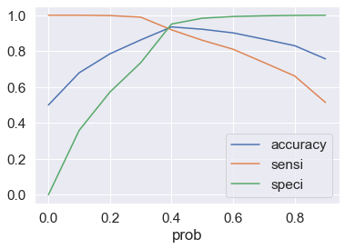

```python
# Finding optimal cut-off probability
PlotOptimalCutoff(y_train_df)
```

```python
# change accordingly
#Selecting 0.45 as cut-off in an attempt to improve recall rate
cut_off_prob=0.45
PredictSentimentsWithProbability(xgb_final,test_tfidf,y_test,cut_off_prob)
```

```
Sensitivity/Recall : 0.8652694610778443
Specificity: 0.7545731707317073
False Positive Rate: 0.24542682926829268
Positive predictive value: 0.9663531870428422
Negative Predictive value: 0.4074074074074074
sklearn precision score value: 0.9663531870428422
```

|  | sentiments | sentiments_prob | final_predicted |
| --- | --- | --- | --- |
| 17173 | 1.0 | 0.982612 | 1 |
| 28361 | 1.0 | 0.607781 | 1 |
| 18990 | 1.0 | 0.478829 | 1 |
| 1948 | 1.0 | 0.579887 | 1 |
| 10283 | 1.0 | 0.630047 | 1 |
| ... | ... | ... | ... |
| 15439 | 1.0 | 0.587364 | 1 |
| 8578 | 1.0 | 0.891908 | 1 |
| 19714 | 1.0 | 0.976140 | 1 |
| 5865 | 1.0 | 0.988354 | 1 |
| 669 | 1.0 | 0.537101 | 1 |

6000 rows × 3 columns

- comparing train and test auc curves

```
AUC for train 0.9590925718997209
AUC for test 0.8990797463761501
```

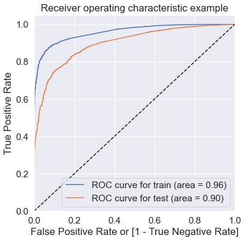

```python
xgb_train_proba=xgb_final.predict_proba(train_tfidf)[:,1]
xgb_test_proba=xgb_final.predict_proba(test_tfidf)[:,1]
fpr,tpr,thresholds=metrics.roc_curve(y_train,xgb_train_proba)
fpr1,tpr1,thresholds1=metrics.roc_curve(y_test,xgb_test_proba)
print("AUC for train" , metrics.auc(fpr,tpr))
print("AUC for test" , metrics.auc(fpr1,tpr1))
plt.figure(figsize=(6, 6))
plt.plot( fpr, tpr, label='ROC curve for train (area = %0.2f)' % metrics.auc(fpr,tpr ))
plt.plot( fpr1, tpr1, label='ROC curve for test (area = %0.2f)' % metrics.auc(fpr1,tpr1) )
plt.plot([0, 1], [0, 1], 'k--')
plt.xlim([0.0, 1.0])
plt.ylim([0.0, 1.05])
plt.xlabel('False Positive Rate or [1 - True Negative Rate]')
plt.ylabel('True Positive Rate')
plt.title('Receiver operating characteristic example')
plt.legend(loc="lower right")
plt.show()
```

- train sensitivity 0.86 auc 0.96
- test sensitivity 0.86 auc 0.90

### Multinomial Naive Bayes

```python
# building a multinomial NB model
from sklearn.naive_bayes import MultinomialNB

# instantiate NB class
mnb_model=MultinomialNB()
```

- fitting mnb model and finding the metrics for train data

```python
FitModel(mnb_model, X_train_smote, y_train_smote)
```

```
Model Report
Accuracy : 0.8983
Recall/Sensitivity : 0.8769
```

```python
mnb_pred_train=mnb_model.predict(X_train_smote)
```

```python
# Model evaluation on Test data
ModelMetrics(y_train_smote,mnb_pred_train)
```

```
Sensitivity/Recall : 0.8768789928598272
Specificity: 0.9198139797068771
False Positive Rate: 0.08018602029312288
Positive predictive value: 0.9162167468342004
Negative Predictive value: 0.8819475722907846
sklearn precision score value: 0.9162167468342004
```

- Prediction on Test data

```python
mnb_pred_test = mnb_model.predict(test_tfidf)
```

```python
# Model evaluation on Test data
ModelMetrics(y_test,mnb_pred_test)
```

```
Sensitivity/Recall : 0.8607784431137725
Specificity: 0.6524390243902439
False Positive Rate: 0.3475609756097561
Positive predictive value: 0.9527754763877382
Negative Predictive value: 0.3651877133105802
sklearn precision score value: 0.9527754763877382
```

```python
print("Accuracy for test: {}".format(metrics.accuracy_score(y_test,mnb_pred_test)))
print("Recall for test: {}".format(metrics.recall_score(y_test,mnb_pred_test)))
print("Precision for test: {}".format(metrics.precision_score(y_test,mnb_pred_test)))
```

```
Accuracy for test: 0.838
Recall for test: 0.8607784431137725
Precision for test: 0.9527754763877382
```

- comparing train and test auc curves

```
AUC for train 0.950239620106596
AUC for test 0.8598117218307288
```

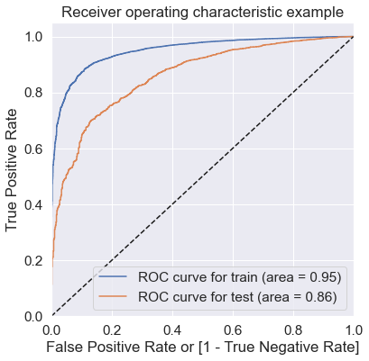

```python
mnb_train_proba=mnb_model.predict_proba(train_tfidf)[:,1]
mnb_test_proba=mnb_model.predict_proba(test_tfidf)[:,1]
fpr,tpr,thresholds=metrics.roc_curve(y_train,mnb_train_proba)
fpr1,tpr1,thresholds1=metrics.roc_curve(y_test,mnb_test_proba)
print("AUC for train" , metrics.auc(fpr,tpr))
print("AUC for test" , metrics.auc(fpr1,tpr1))
plt.figure(figsize=(6, 6))
plt.plot( fpr, tpr, label='ROC curve for train (area = %0.2f)' % metrics.auc(fpr,tpr ))
plt.plot( fpr1, tpr1, label='ROC curve for test (area = %0.2f)' % metrics.auc(fpr1,tpr1) )
plt.plot([0, 1], [0, 1], 'k--')
plt.xlim([0.0, 1.0])
plt.ylim([0.0, 1.05])
plt.xlabel('False Positive Rate or [1 - True Negative Rate]')
plt.ylabel('True Positive Rate')
plt.title('Receiver operating characteristic example')
plt.legend(loc="lower right")
plt.show()
```

train sensitivity 0.87 auc 0.95  
test sensitivity 0.86 auc 0.86

### Results for ML Models

- LR Model
  - train sensititvity 0.92
  - test sensitivity 0.89
- Random Forest
  - performs poorly
- Boosting
  - XGBOOST
    - train sensititvity 0.86
    - test sensitivity 0.86
  - GRADIENT BOOSTING
    - train sensititvity 0.84
    - test sensitivity 0.83
- MNB
  - train sensititvity 0.87
  - test sensitivity 0.86
- **from the above we finalise that LR Model is simple and performs best.**

### Recommendation systems

#### User-based

- There are many duplicates it means user has rated the same product multiple times so iam considering the average ratings from all such duplicate entries

```python
##reviews_df[['id','name','reviews_rating']][reviews_df[['id','name','reviews_rating']].duplicated()]
```

```python
reviews_df=reviews_df.groupby(['reviews_username','name'])['reviews_rating'].mean().reset_index()
```

### Test and Train split of the dataset.

```python
from sklearn.model_selection import train_test_split
train, test = train_test_split(reviews_df, test_size=0.30, random_state=seed)
```

```python
print(train.shape)
print(test.shape)
```

```
(19311, 3)
(8277, 3)
```

```python
train.head(2)
```

|  | reviews_username | name | reviews_rating |
| --- | --- | --- | --- |
| 22234 | ruth | Clorox Disinfecting Wipes Value Pack Scented 1... | 5.0 |
| 24652 | superd | Tostitos Bite Size Tortilla Chips | 5.0 |

- pivoting the train dataset by the below index and columns and converting into matrix format

```python
user_pivot = train.pivot(
    index='reviews_username',
    columns='name',
    values='reviews_rating'
).fillna(0)

user_pivot.head(3)
```

| name reviews_username | 0.6 Cu. Ft. Letter A4 Size Waterproof 30 Min. Fire File Chest | 100:Complete First Season (blu-Ray) | 2017-2018 Brownline174 Duraflex 14-Month Planner 8 1/2 X 11 Black | 2x Ultra Era with Oxi Booster, 50fl oz | 4C Grated Parmesan Cheese 100% Natural 8oz Shaker | Africa's Best No-Lye Dual Conditioning Relaxer System Super | Alberto VO5 Salon Series Smooth Plus Sleek Shampoo | Alex Cross (dvdvideo) | All,bran Complete Wheat Flakes, 18 Oz. | Ambi Complexion Cleansing Bar | ... | Voortman Sugar Free Fudge Chocolate Chip Cookies | Wagan Smartac 80watt Inverter With Usb | Wallmount Server Cabinet (450mm, 9 RU) | Way Basics 3-Shelf Eco Narrow Bookcase Storage Shelf, Espresso - Formaldehyde Free - Lifetime Guarantee | WeatherTech 40647 14-15 Outlander Cargo Liners Behind 2nd Row, Black | Weleda Everon Lip Balm | Wilton Black Dots Standard Baking Cups | Windex Original Glass Cleaner Refill 67.6oz (2 Liter) | Yes To Carrots Nourishing Body Wash | Yes To Grapefruit Rejuvenating Body Wash |
| --- | --- | --- | --- | --- | --- | --- | --- | --- | --- | --- | --- | --- | --- | --- | --- | --- | --- | --- | --- | --- | --- |
| 02dakota | 0.0 | 0.0 | 0.0 | 0.0 | 0.0 | 0.0 | 0.0 | 0.0 | 0.0 | 0.0 | ... | 0.0 | 0.0 | 0.0 | 0.0 | 0.0 | 0.0 | 0.0 | 0.0 | 0.0 | 0.0 |
| 02deuce | 0.0 | 0.0 | 0.0 | 0.0 | 0.0 | 0.0 | 0.0 | 0.0 | 0.0 | 0.0 | ... | 0.0 | 0.0 | 0.0 | 0.0 | 0.0 | 0.0 | 0.0 | 0.0 | 0.0 | 0.0 |
| 06stidriver | 0.0 | 0.0 | 0.0 | 0.0 | 0.0 | 0.0 | 0.0 | 0.0 | 0.0 | 0.0 | ... | 0.0 | 0.0 | 0.0 | 0.0 | 0.0 | 0.0 | 0.0 | 0.0 | 0.0 | 0.0 |

3 rows × 248 columns

### dummy train & dummy test dataset

These dataset will be used for prediction

- To ignore the products already rated by user we will substitute with zero suring prediction and remaining ones by 1
- Dummy test will be used for evaluation. To evaluate, we will only make prediction on the products rated by the common users in train and test. So, this is marked as 1.

```python
# Copy the train dataset into dummy_train
dummy_train = train.copy()
```

```python
# The products not rated by user is marked as 1 for prediction.
dummy_train['reviews_rating'] = dummy_train['reviews_rating'].apply(lambda x: 0 if x>=1 else 1)
```

```python
# Convert the dummy train dataset into matrix format.
dummy_train = dummy_train.pivot(
    index='reviews_username',
    columns='name',
    values='reviews_rating'
).fillna(1)
```

```python
dummy_train.shape
```

```
(17838, 248)
```

```python
dummy_train.head()
```

| name reviews_username | 0.6 Cu. Ft. Letter A4 Size Waterproof 30 Min. Fire File Chest | 100:Complete First Season (blu-Ray) | 2017-2018 Brownline174 Duraflex 14-Month Planner 8 1/2 X 11 Black | 2x Ultra Era with Oxi Booster, 50fl oz | 4C Grated Parmesan Cheese 100% Natural 8oz Shaker | Africa's Best No-Lye Dual Conditioning Relaxer System Super | Alberto VO5 Salon Series Smooth Plus Sleek Shampoo | Alex Cross (dvdvideo) | All,bran Complete Wheat Flakes, 18 Oz. | Ambi Complexion Cleansing Bar | ... | Voortman Sugar Free Fudge Chocolate Chip Cookies | Wagan Smartac 80watt Inverter With Usb | Wallmount Server Cabinet (450mm, 9 RU) | Way Basics 3-Shelf Eco Narrow Bookcase Storage Shelf, Espresso - Formaldehyde Free - Lifetime Guarantee | WeatherTech 40647 14-15 Outlander Cargo Liners Behind 2nd Row, Black | Weleda Everon Lip Balm | Wilton Black Dots Standard Baking Cups | Windex Original Glass Cleaner Refill 67.6oz (2 Liter) | Yes To Carrots Nourishing Body Wash | Yes To Grapefruit Rejuvenating Body Wash |
| --- | --- | --- | --- | --- | --- | --- | --- | --- | --- | --- | --- | --- | --- | --- | --- | --- | --- | --- | --- | --- | --- |
| 02dakota | 1.0 | 1.0 | 1.0 | 1.0 | 1.0 | 1.0 | 1.0 | 1.0 | 1.0 | 1.0 | ... | 1.0 | 1.0 | 1.0 | 1.0 | 1.0 | 1.0 | 1.0 | 1.0 | 1.0 | 1.0 |
| 02deuce | 1.0 | 1.0 | 1.0 | 1.0 | 1.0 | 1.0 | 1.0 | 1.0 | 1.0 | 1.0 | ... | 1.0 | 1.0 | 1.0 | 1.0 | 1.0 | 1.0 | 1.0 | 1.0 | 1.0 | 1.0 |
| 06stidriver | 1.0 | 1.0 | 1.0 | 1.0 | 1.0 | 1.0 | 1.0 | 1.0 | 1.0 | 1.0 | ... | 1.0 | 1.0 | 1.0 | 1.0 | 1.0 | 1.0 | 1.0 | 1.0 | 1.0 | 1.0 |
| 08dallas | 1.0 | 0.0 | 1.0 | 1.0 | 1.0 | 1.0 | 1.0 | 1.0 | 1.0 | 1.0 | ... | 1.0 | 1.0 | 1.0 | 1.0 | 1.0 | 1.0 | 1.0 | 1.0 | 1.0 | 1.0 |
| 09mommy11 | 1.0 | 1.0 | 1.0 | 1.0 | 1.0 | 1.0 | 1.0 | 1.0 | 1.0 | 1.0 | ... | 1.0 | 1.0 | 1.0 | 1.0 | 1.0 | 1.0 | 1.0 | 1.0 | 1.0 | 1.0 |

5 rows × 248 columns

### Using adjusted Cosine

```python
# Create a user-product matrix.
user_pivot = train.pivot(
    index='reviews_username',
    columns='name',
    values='reviews_rating'
)
```

```python
user_pivot.head()
```

| name reviews_username | 0.6 Cu. Ft. Letter A4 Size Waterproof 30 Min. Fire File Chest | 100:Complete First Season (blu-Ray) | 2017-2018 Brownline174 Duraflex 14-Month Planner 8 1/2 X 11 Black | 2x Ultra Era with Oxi Booster, 50fl oz | 4C Grated Parmesan Cheese 100% Natural 8oz Shaker | Africa's Best No-Lye Dual Conditioning Relaxer System Super | Alberto VO5 Salon Series Smooth Plus Sleek Shampoo | Alex Cross (dvdvideo) | All,bran Complete Wheat Flakes, 18 Oz. | Ambi Complexion Cleansing Bar | ... | Voortman Sugar Free Fudge Chocolate Chip Cookies | Wagan Smartac 80watt Inverter With Usb | Wallmount Server Cabinet (450mm, 9 RU) | Way Basics 3-Shelf Eco Narrow Bookcase Storage Shelf, Espresso - Formaldehyde Free - Lifetime Guarantee | WeatherTech 40647 14-15 Outlander Cargo Liners Behind 2nd Row, Black | Weleda Everon Lip Balm | Wilton Black Dots Standard Baking Cups | Windex Original Glass Cleaner Refill 67.6oz (2 Liter) | Yes To Carrots Nourishing Body Wash | Yes To Grapefruit Rejuvenating Body Wash |
| --- | --- | --- | --- | --- | --- | --- | --- | --- | --- | --- | --- | --- | --- | --- | --- | --- | --- | --- | --- | --- | --- |
| 02dakota | NaN | NaN | NaN | NaN | NaN | NaN | NaN | NaN | NaN | NaN | ... | NaN | NaN | NaN | NaN | NaN | NaN | NaN | NaN | NaN | NaN |
| 02deuce | NaN | NaN | NaN | NaN | NaN | NaN | NaN | NaN | NaN | NaN | ... | NaN | NaN | NaN | NaN | NaN | NaN | NaN | NaN | NaN | NaN |
| 06stidriver | NaN | NaN | NaN | NaN | NaN | NaN | NaN | NaN | NaN | NaN | ... | NaN | NaN | NaN | NaN | NaN | NaN | NaN | NaN | NaN | NaN |
| 08dallas | NaN | 5.0 | NaN | NaN | NaN | NaN | NaN | NaN | NaN | NaN | ... | NaN | NaN | NaN | NaN | NaN | NaN | NaN | NaN | NaN | NaN |
| 09mommy11 | NaN | NaN | NaN | NaN | NaN | NaN | NaN | NaN | NaN | NaN | ... | NaN | NaN | NaN | NaN | NaN | NaN | NaN | NaN | NaN | NaN |

5 rows × 248 columns

### Normalising the product ratings

```python
mean = np.nanmean(user_pivot, axis=1)
df_subtracted = (user_pivot.T-mean).T
```

```python
df_subtracted.head()
```

| name reviews_username | 0.6 Cu. Ft. Letter A4 Size Waterproof 30 Min. Fire File Chest | 100:Complete First Season (blu-Ray) | 2017-2018 Brownline174 Duraflex 14-Month Planner 8 1/2 X 11 Black | 2x Ultra Era with Oxi Booster, 50fl oz | 4C Grated Parmesan Cheese 100% Natural 8oz Shaker | Africa's Best No-Lye Dual Conditioning Relaxer System Super | Alberto VO5 Salon Series Smooth Plus Sleek Shampoo | Alex Cross (dvdvideo) | All,bran Complete Wheat Flakes, 18 Oz. | Ambi Complexion Cleansing Bar | ... | Voortman Sugar Free Fudge Chocolate Chip Cookies | Wagan Smartac 80watt Inverter With Usb | Wallmount Server Cabinet (450mm, 9 RU) | Way Basics 3-Shelf Eco Narrow Bookcase Storage Shelf, Espresso - Formaldehyde Free - Lifetime Guarantee | WeatherTech 40647 14-15 Outlander Cargo Liners Behind 2nd Row, Black | Weleda Everon Lip Balm | Wilton Black Dots Standard Baking Cups | Windex Original Glass Cleaner Refill 67.6oz (2 Liter) | Yes To Carrots Nourishing Body Wash | Yes To Grapefruit Rejuvenating Body Wash |
| --- | --- | --- | --- | --- | --- | --- | --- | --- | --- | --- | --- | --- | --- | --- | --- | --- | --- | --- | --- | --- | --- |
| 02dakota | NaN | NaN | NaN | NaN | NaN | NaN | NaN | NaN | NaN | NaN | ... | NaN | NaN | NaN | NaN | NaN | NaN | NaN | NaN | NaN | NaN |
| 02deuce | NaN | NaN | NaN | NaN | NaN | NaN | NaN | NaN | NaN | NaN | ... | NaN | NaN | NaN | NaN | NaN | NaN | NaN | NaN | NaN | NaN |
| 06stidriver | NaN | NaN | NaN | NaN | NaN | NaN | NaN | NaN | NaN | NaN | ... | NaN | NaN | NaN | NaN | NaN | NaN | NaN | NaN | NaN | NaN |
| 08dallas | NaN | 0.0 | NaN | NaN | NaN | NaN | NaN | NaN | NaN | NaN | ... | NaN | NaN | NaN | NaN | NaN | NaN | NaN | NaN | NaN | NaN |
| 09mommy11 | NaN | NaN | NaN | NaN | NaN | NaN | NaN | NaN | NaN | NaN | ... | NaN | NaN | NaN | NaN | NaN | NaN | NaN | NaN | NaN | NaN |

5 rows × 248 columns

### Finding cosine similarity

```python
from sklearn.metrics.pairwise import pairwise_distances
```

```python
# Creating the User Similarity Matrix using pairwise_distance function.
user_correlation = 1 - pairwise_distances(df_subtracted.fillna(0), metric='cosine')
user_correlation[np.isnan(user_correlation)] = 0
print(user_correlation)
```

```
[[0. 0. 0. ... 0. 0. 0.]
 [0. 0. 0. ... 0. 0. 0.]
 [0. 0. 0. ... 0. 0. 0.]
 ...
 [0. 0. 0. ... 0. 0. 0.]
 [0. 0. 0. ... 0. 0. 0.]
 [0. 0. 0. ... 0. 0. 0.]]
```

### Prediction - User User

- Here we are more intrested in finding the similar users who are correlated to each other so lets ignore the correlation values which are lesser than zero

```python
user_correlation[user_correlation<0]=0
user_correlation
```

```
array([[0., 0., 0., ..., 0., 0., 0.],
       [0., 0., 0., ..., 0., 0., 0.],
       [0., 0., 0., ..., 0., 0., 0.],
       ...,
       [0., 0., 0., ..., 0., 0., 0.],
       [0., 0., 0., ..., 0., 0., 0.],
       [0., 0., 0., ..., 0., 0., 0.]])
```

Finding the predicted ratings by the weighted sum of correlation with the user rating

```python
user_predicted_ratings = np.dot(user_correlation, user_pivot.fillna(0))
user_predicted_ratings
```

```
array([[0., 0., 0., ..., 0., 0., 0.],
       [0., 0., 0., ..., 0., 0., 0.],
       [0., 0., 0., ..., 0., 0., 0.],
       ...,
       [0., 0., 0., ..., 0., 0., 0.],
       [0., 0., 0., ..., 0., 0., 0.],
       [0., 0., 0., ..., 0., 0., 0.]])
```

```python
user_predicted_ratings.shape
```

```
(17838, 248)
```

Here we are multiplying as below because we are ignoring the user ratings given for a product by making zero

```python
user_final_rating = np.multiply(user_predicted_ratings,dummy_train)
user_final_rating.head()
```

| name reviews_username | 0.6 Cu. Ft. Letter A4 Size Waterproof 30 Min. Fire File Chest | 100:Complete First Season (blu-Ray) | 2017-2018 Brownline174 Duraflex 14-Month Planner 8 1/2 X 11 Black | 2x Ultra Era with Oxi Booster, 50fl oz | 4C Grated Parmesan Cheese 100% Natural 8oz Shaker | Africa's Best No-Lye Dual Conditioning Relaxer System Super | Alberto VO5 Salon Series Smooth Plus Sleek Shampoo | Alex Cross (dvdvideo) | All,bran Complete Wheat Flakes, 18 Oz. | Ambi Complexion Cleansing Bar | ... | Voortman Sugar Free Fudge Chocolate Chip Cookies | Wagan Smartac 80watt Inverter With Usb | Wallmount Server Cabinet (450mm, 9 RU) | Way Basics 3-Shelf Eco Narrow Bookcase Storage Shelf, Espresso - Formaldehyde Free - Lifetime Guarantee | WeatherTech 40647 14-15 Outlander Cargo Liners Behind 2nd Row, Black | Weleda Everon Lip Balm | Wilton Black Dots Standard Baking Cups | Windex Original Glass Cleaner Refill 67.6oz (2 Liter) | Yes To Carrots Nourishing Body Wash | Yes To Grapefruit Rejuvenating Body Wash |
| --- | --- | --- | --- | --- | --- | --- | --- | --- | --- | --- | --- | --- | --- | --- | --- | --- | --- | --- | --- | --- | --- |
| 02dakota | 0.0 | 0.0 | 0.0 | 0.0 | 0.0 | 0.0 | 0.0 | 0.0 | 0.0 | 0.0 | ... | 0.0 | 0.0 | 0.0 | 0.0 | 0.0 | 0.0 | 0.0 | 0.0 | 0.0 | 0.0 |
| 02deuce | 0.0 | 0.0 | 0.0 | 0.0 | 0.0 | 0.0 | 0.0 | 0.0 | 0.0 | 0.0 | ... | 0.0 | 0.0 | 0.0 | 0.0 | 0.0 | 0.0 | 0.0 | 0.0 | 0.0 | 0.0 |
| 06stidriver | 0.0 | 0.0 | 0.0 | 0.0 | 0.0 | 0.0 | 0.0 | 0.0 | 0.0 | 0.0 | ... | 0.0 | 0.0 | 0.0 | 0.0 | 0.0 | 0.0 | 0.0 | 0.0 | 0.0 | 0.0 |
| 08dallas | 0.0 | 0.0 | 0.0 | 0.0 | 0.0 | 0.0 | 0.0 | 0.0 | 0.0 | 0.0 | ... | 0.0 | 0.0 | 0.0 | 0.0 | 0.0 | 0.0 | 0.0 | 0.0 | 0.0 | 0.0 |
| 09mommy11 | 0.0 | 0.0 | 0.0 | 0.0 | 0.0 | 0.0 | 0.0 | 0.0 | 0.0 | 0.0 | ... | 0.0 | 0.0 | 0.0 | 0.0 | 0.0 | 0.0 | 0.0 | 0.0 | 0.0 | 0.0 |

5 rows × 248 columns

Exporting to csv file

```python
#user_final_rating.to_csv("userpredictions.csv")
```

```python
# Take the user ID as input.
user_input = "rebecca"
print(user_input)
```

```
rebecca
```

```python
user_final_rating.head(2)
```

| name reviews_username | 0.6 Cu. Ft. Letter A4 Size Waterproof 30 Min. Fire File Chest | 100:Complete First Season (blu-Ray) | 2017-2018 Brownline174 Duraflex 14-Month Planner 8 1/2 X 11 Black | 2x Ultra Era with Oxi Booster, 50fl oz | 4C Grated Parmesan Cheese 100% Natural 8oz Shaker | Africa's Best No-Lye Dual Conditioning Relaxer System Super | Alberto VO5 Salon Series Smooth Plus Sleek Shampoo | Alex Cross (dvdvideo) | All,bran Complete Wheat Flakes, 18 Oz. | Ambi Complexion Cleansing Bar | ... | Voortman Sugar Free Fudge Chocolate Chip Cookies | Wagan Smartac 80watt Inverter With Usb | Wallmount Server Cabinet (450mm, 9 RU) | Way Basics 3-Shelf Eco Narrow Bookcase Storage Shelf, Espresso - Formaldehyde Free - Lifetime Guarantee | WeatherTech 40647 14-15 Outlander Cargo Liners Behind 2nd Row, Black | Weleda Everon Lip Balm | Wilton Black Dots Standard Baking Cups | Windex Original Glass Cleaner Refill 67.6oz (2 Liter) | Yes To Carrots Nourishing Body Wash | Yes To Grapefruit Rejuvenating Body Wash |
| --- | --- | --- | --- | --- | --- | --- | --- | --- | --- | --- | --- | --- | --- | --- | --- | --- | --- | --- | --- | --- | --- |
| 02dakota | 0.0 | 0.0 | 0.0 | 0.0 | 0.0 | 0.0 | 0.0 | 0.0 | 0.0 | 0.0 | ... | 0.0 | 0.0 | 0.0 | 0.0 | 0.0 | 0.0 | 0.0 | 0.0 | 0.0 | 0.0 |
| 02deuce | 0.0 | 0.0 | 0.0 | 0.0 | 0.0 | 0.0 | 0.0 | 0.0 | 0.0 | 0.0 | ... | 0.0 | 0.0 | 0.0 | 0.0 | 0.0 | 0.0 | 0.0 | 0.0 | 0.0 | 0.0 |

2 rows × 248 columns

### Top 20 recommendations to user

```python
top20 = user_final_rating.loc[user_input].sort_values(ascending=False)[0:20]
top20
#user_final_rating.loc[user_input].sort_values()[-20:]
#pd.DataFrame(user_final_rating.loc[user_input]).rename(columns={"name": "name", user_input: "reviews_rating"}).sort_values(by="reviews_rating",ascending=False)[0:20]
```

```
name
Godzilla 3d Includes Digital Copy Ultraviolet 3d/2d Blu-Ray/dvd                                  21.746477
My Big Fat Greek Wedding 2 (blu-Ray + Dvd + Digital)                                              9.025315
Mike Dave Need Wedding Dates (dvd + Digital)                                                      8.564350
Burt's Bees Lip Shimmer, Raisin                                                                   5.356288
Hoover174 Platinum Collection153 Lightweight Bagged Upright Vacuum With Canister - Uh30010com     4.881741
Coty Airspun Face Powder, Translucent Extra Coverage                                              4.127450
The Honest Company Laundry Detergent                                                              3.963380
Boraam Sonoma Kitchen Cart With Wire Brush Gray - Maaya Home                                      3.766211
The Resident Evil Collection 5 Discs (blu-Ray)                                                    3.464385
Pendaflex174 Divide It Up File Folder, Multi Section, Letter, Assorted, 12/pack                   3.089679
Chester's Cheese Flavored Puffcorn Snacks                                                         3.041192
Power Crunch Protein Energy Bar Peanut Butter Creme Original                                      2.396096
Vicks Vaporub, Regular, 3.53oz                                                                    1.560537
Bisquick Original Pancake And Baking Mix - 40oz                                                   1.549511
Windex Original Glass Cleaner Refill 67.6oz (2 Liter)                                             1.513628
Ragu Roasted Garlic Parmesan Pasta Sauce                                                          1.433619
Alex Cross (dvdvideo)                                                                             1.381417
Australian Gold Exotic Blend Lotion, SPF 4                                                        1.296190
Clorox Disinfecting Bathroom Cleaner                                                              1.265018
Chips Ahoy! Original Chocolate Chip - Cookies - Family Size 18.2oz                                1.143107
Name: rebecca, dtype: float64
```

### Evaluation - User User

```python
# Find out the common users of test and train dataset.
common = test[test.reviews_username.isin(train.reviews_username)]
common.shape
```

```
(1076, 3)
```

```python
common.head()
```

|  | reviews_username | name | reviews_rating |
| --- | --- | --- | --- |
| 25745 | timothy | My Big Fat Greek Wedding 2 (blu-Ray + Dvd + Di... | 5.0 |
| 14641 | lance | Godzilla 3d Includes Digital Copy Ultraviolet ... | 4.0 |
| 11481 | jean | Clorox Disinfecting Wipes Value Pack Scented 1... | 5.0 |
| 24661 | supergirl | L'or233al Paris Elvive Extraordinary Clay Reba... | 4.0 |
| 18637 | mrfrost | Mike Dave Need Wedding Dates (dvd + Digital) | 5.0 |

```python
# convert into the user-product matrix.
common_user_based_matrix = common.pivot_table(index='reviews_username', columns='name', values='reviews_rating')
```

```python
common_user_based_matrix.shape
```

```
(915, 113)
```

```python
# Convert the user_correlation matrix into dataframe.
user_correlation_df = pd.DataFrame(user_correlation)
```

```python
df_subtracted.head(1)
```

| name reviews_username | 0.6 Cu. Ft. Letter A4 Size Waterproof 30 Min. Fire File Chest | 100:Complete First Season (blu-Ray) | 2017-2018 Brownline174 Duraflex 14-Month Planner 8 1/2 X 11 Black | 2x Ultra Era with Oxi Booster, 50fl oz | 4C Grated Parmesan Cheese 100% Natural 8oz Shaker | Africa's Best No-Lye Dual Conditioning Relaxer System Super | Alberto VO5 Salon Series Smooth Plus Sleek Shampoo | Alex Cross (dvdvideo) | All,bran Complete Wheat Flakes, 18 Oz. | Ambi Complexion Cleansing Bar | ... | Voortman Sugar Free Fudge Chocolate Chip Cookies | Wagan Smartac 80watt Inverter With Usb | Wallmount Server Cabinet (450mm, 9 RU) | Way Basics 3-Shelf Eco Narrow Bookcase Storage Shelf, Espresso - Formaldehyde Free - Lifetime Guarantee | WeatherTech 40647 14-15 Outlander Cargo Liners Behind 2nd Row, Black | Weleda Everon Lip Balm | Wilton Black Dots Standard Baking Cups | Windex Original Glass Cleaner Refill 67.6oz (2 Liter) | Yes To Carrots Nourishing Body Wash | Yes To Grapefruit Rejuvenating Body Wash |
| --- | --- | --- | --- | --- | --- | --- | --- | --- | --- | --- | --- | --- | --- | --- | --- | --- | --- | --- | --- | --- | --- |
| 02dakota | NaN | NaN | NaN | NaN | NaN | NaN | NaN | NaN | NaN | NaN | ... | NaN | NaN | NaN | NaN | NaN | NaN | NaN | NaN | NaN | NaN |

1 rows × 248 columns

```python
user_correlation_df['reviews_username'] = df_subtracted.index
user_correlation_df.set_index('reviews_username',inplace=True)
user_correlation_df.head()
```

| reviews_username | 0 | 1 | 2 | 3 | 4 | 5 | 6 | 7 | 8 | 9 | ... | 17828 | 17829 | 17830 | 17831 | 17832 | 17833 | 17834 | 17835 | 17836 | 17837 |
| --- | --- | --- | --- | --- | --- | --- | --- | --- | --- | --- | --- | --- | --- | --- | --- | --- | --- | --- | --- | --- | --- |
| 02dakota | 0.0 | 0.0 | 0.0 | 0.0 | 0.0 | 0.0 | 0.0 | 0.0 | 0.0 | 0.0 | ... | 0.0 | 0.0 | 0.0 | 0.0 | 0.0 | 0.0 | 0.0 | 0.0 | 0.0 | 0.0 |
| 02deuce | 0.0 | 0.0 | 0.0 | 0.0 | 0.0 | 0.0 | 0.0 | 0.0 | 0.0 | 0.0 | ... | 0.0 | 0.0 | 0.0 | 0.0 | 0.0 | 0.0 | 0.0 | 0.0 | 0.0 | 0.0 |
| 06stidriver | 0.0 | 0.0 | 0.0 | 0.0 | 0.0 | 0.0 | 0.0 | 0.0 | 0.0 | 0.0 | ... | 0.0 | 0.0 | 0.0 | 0.0 | 0.0 | 0.0 | 0.0 | 0.0 | 0.0 | 0.0 |
| 08dallas | 0.0 | 0.0 | 0.0 | 0.0 | 0.0 | 0.0 | 0.0 | 0.0 | 0.0 | 0.0 | ... | 0.0 | 0.0 | 0.0 | 0.0 | 0.0 | 0.0 | 0.0 | 0.0 | 0.0 | 0.0 |
| 09mommy11 | 0.0 | 0.0 | 0.0 | 0.0 | 0.0 | 0.0 | 0.0 | 0.0 | 0.0 | 0.0 | ... | 0.0 | 0.0 | 0.0 | 0.0 | 0.0 | 0.0 | 0.0 | 0.0 | 0.0 | 0.0 |

5 rows × 17838 columns

```python
common.head(1)
```

|  | reviews_username | name | reviews_rating |
| --- | --- | --- | --- |
| 25745 | timothy | My Big Fat Greek Wedding 2 (blu-Ray + Dvd + Di... | 5.0 |

```python
list_name = common.reviews_username.tolist()

user_correlation_df.columns = df_subtracted.index.tolist()


user_correlation_df_1 =  user_correlation_df[user_correlation_df.index.isin(list_name)]
```

```python
user_correlation_df_1.shape
```

```
(915, 17838)
```

```python
user_correlation_df_2 = user_correlation_df_1.T[user_correlation_df_1.T.index.isin(list_name)]
```

```python
user_correlation_df_3 = user_correlation_df_2.T
```

```python
user_correlation_df_3.head()
```

| reviews_username | 1234 | 123charlie | 1witch | 37f5p | 50cal | abbey | abby | acv4217 | adam | aep1010 | ... | woody | woottos | xmom | xstr8edgex | yohnie1 | yummy | yvonne | zipper | zippy | zitro |
| --- | --- | --- | --- | --- | --- | --- | --- | --- | --- | --- | --- | --- | --- | --- | --- | --- | --- | --- | --- | --- | --- |
| 1234 | 1.0 | 0.0 | 0.0 | 0.0 | 0.0 | 0.0 | 0.0 | 0.0 | 0.0 | 0.0 | ... | 0.0 | 0.0 | 0.0 | 0.0 | 0.0 | 0.0 | 0.0 | 0.0 | 0.288675 | 0.0 |
| 123charlie | 0.0 | 0.0 | 0.0 | 0.0 | 0.0 | 0.0 | 0.0 | 0.0 | 0.0 | 0.0 | ... | 0.0 | 0.0 | 0.0 | 0.0 | 0.0 | 0.0 | 0.0 | 0.0 | 0.000000 | 0.0 |
| 1witch | 0.0 | 0.0 | 0.0 | 0.0 | 0.0 | 0.0 | 0.0 | 0.0 | 0.0 | 0.0 | ... | 0.0 | 0.0 | 0.0 | 0.0 | 0.0 | 0.0 | 0.0 | 0.0 | 0.000000 | 0.0 |
| 37f5p | 0.0 | 0.0 | 0.0 | 0.0 | 0.0 | 0.0 | 0.0 | 0.0 | 0.0 | 0.0 | ... | 0.0 | 0.0 | 0.0 | 0.0 | 0.0 | 0.0 | 0.0 | 0.0 | 0.000000 | 0.0 |
| 50cal | 0.0 | 0.0 | 0.0 | 0.0 | 0.0 | 0.0 | 0.0 | 0.0 | 0.0 | 0.0 | ... | 0.0 | 0.0 | 0.0 | 0.0 | 0.0 | 0.0 | 0.0 | 0.0 | 0.000000 | 0.0 |

5 rows × 915 columns

```python
user_correlation_df_3.shape
#common_user_based_matrix.shape
```

```
(915, 915)
```

```python
user_correlation_df_3[user_correlation_df_3<0]=0

common_user_predicted_ratings = np.dot(user_correlation_df_3, common_user_based_matrix.fillna(0))
common_user_predicted_ratings
```

```
array([[0.        , 3.11004234, 0.        , ..., 0.        , 0.04848811,
        1.15470054],
       [0.        , 0.        , 0.        , ..., 0.        , 0.        ,
        0.        ],
       [0.        , 0.        , 0.        , ..., 0.        , 0.        ,
        0.        ],
       ...,
       [0.        , 0.        , 0.        , ..., 0.        , 0.        ,
        0.        ],
       [0.        , 5.38675135, 0.        , ..., 0.        , 2.90949434,
        2.        ],
       [0.        , 0.        , 0.        , ..., 0.        , 0.        ,
        0.        ]])
```

```python
dummy_test = common.copy()

dummy_test['reviews_rating'] = dummy_test['reviews_rating'].apply(lambda x: 1 if x>=1 else 0)

dummy_test = dummy_test.pivot_table(index='reviews_username', columns='name', values='reviews_rating').fillna(0)
```

```python
dummy_test.shape
```

```
(915, 113)
```

```python
common_user_predicted_ratings = np.multiply(common_user_predicted_ratings,dummy_test)
```

```python
common_user_predicted_ratings.head(2)
```

| name reviews_username | 0.6 Cu. Ft. Letter A4 Size Waterproof 30 Min. Fire File Chest | 100:Complete First Season (blu-Ray) | 42 Dual Drop Leaf Table with 2 Madrid Chairs" | Alex Cross (dvdvideo) | Aussie Aussome Volume Shampoo, 13.5 Oz | Australian Gold Exotic Blend Lotion, SPF 4 | Aveeno Baby Continuous Protection Lotion Sunscreen with Broad Spectrum SPF 55, 4oz | Avery174 Ready Index Contemporary Table Of Contents Divider, 1-8, Multi, Letter | BRIDGESTONE 130/70ZR18M/C(63W)FRONT EXEDRA G851, CRUISER RADL | Banana Boat Sunless Summer Color Self Tanning Lotion, Light To Medium | ... | Toy Story Kids' Woody Accessory Kit | Tresemme Kertatin Smooth Infusing Conditioning | Vaseline Intensive Care Healthy Hands Stronger Nails | Vaseline Intensive Care Lip Therapy Cocoa Butter | Vicks Vaporub, Regular, 3.53oz | Voortman Sugar Free Fudge Chocolate Chip Cookies | Wagan Smartac 80watt Inverter With Usb | Way Basics 3-Shelf Eco Narrow Bookcase Storage Shelf, Espresso - Formaldehyde Free - Lifetime Guarantee | Windex Original Glass Cleaner Refill 67.6oz (2 Liter) | Yes To Carrots Nourishing Body Wash |
| --- | --- | --- | --- | --- | --- | --- | --- | --- | --- | --- | --- | --- | --- | --- | --- | --- | --- | --- | --- | --- | --- |
| 1234 | 0.0 | 0.0 | 0.0 | 0.0 | 0.0 | 0.0 | 0.0 | 0.0 | 0.0 | 0.0 | ... | 0.0 | 0.0 | 0.0 | 0.0 | 0.0 | 0.0 | 0.0 | 0.0 | 0.0 | 0.0 |
| 123charlie | 0.0 | 0.0 | 0.0 | 0.0 | 0.0 | 0.0 | 0.0 | 0.0 | 0.0 | 0.0 | ... | 0.0 | 0.0 | 0.0 | 0.0 | 0.0 | 0.0 | 0.0 | 0.0 | 0.0 | 0.0 |

2 rows × 113 columns

### RMSE Calculation

```python
from sklearn.preprocessing import MinMaxScaler
from numpy import *

X  = common_user_predicted_ratings.copy()
X = X[X>0]

scaler = MinMaxScaler(feature_range=(1, 5))
print(scaler.fit(X))
y = (scaler.transform(X))

print(y)
```

```
MinMaxScaler(feature_range=(1, 5))
[[nan nan nan ... nan nan nan]
 [nan nan nan ... nan nan nan]
 [nan nan nan ... nan nan nan]
 ...
 [nan nan nan ... nan nan nan]
 [nan nan nan ... nan nan nan]
 [nan nan nan ... nan nan nan]]
```

```python
common_ = common.pivot_table(index='reviews_username', columns='name', values='reviews_rating')
```

```python
# Finding total non-NaN value
total_non_nan = np.count_nonzero(~np.isnan(y))
```

```python
rmse = (sum(sum((common_ - y )**2))/total_non_nan)**0.5
print(rmse)
```

```
2.5700786852423074
```

### Using Item similarity

- We are transposing the train pivot table to find out the items correlation

```python
item_pivot = train.pivot(
    index='reviews_username',
    columns='name',
    values='reviews_rating'
).T

item_pivot.head()
```

| reviews_username name | 02dakota | 02deuce | 06stidriver | 08dallas | 09mommy11 | 1.11E+24 | 1085 | 10ten | 11111111aaaaaaaaaaaaaaaaa | 11677j | ... | zsarah | zsazsa | zulaa118 | zuttle | zwithanx | zxcsdfd | zxjki | zyiah4 | zzdiane | zzz1127 |
| --- | --- | --- | --- | --- | --- | --- | --- | --- | --- | --- | --- | --- | --- | --- | --- | --- | --- | --- | --- | --- | --- |
| 0.6 Cu. Ft. Letter A4 Size Waterproof 30 Min. Fire File Chest | NaN | NaN | NaN | NaN | NaN | NaN | NaN | NaN | NaN | NaN | ... | NaN | NaN | NaN | NaN | NaN | NaN | NaN | NaN | NaN | NaN |
| 100:Complete First Season (blu-Ray) | NaN | NaN | NaN | 5.0 | NaN | NaN | NaN | NaN | NaN | NaN | ... | NaN | NaN | NaN | NaN | NaN | NaN | NaN | NaN | NaN | NaN |
| 2017-2018 Brownline174 Duraflex 14-Month Planner 8 1/2 X 11 Black | NaN | NaN | NaN | NaN | NaN | NaN | NaN | NaN | NaN | NaN | ... | NaN | NaN | NaN | NaN | NaN | NaN | NaN | NaN | NaN | NaN |
| 2x Ultra Era with Oxi Booster, 50fl oz | NaN | NaN | NaN | NaN | NaN | NaN | NaN | NaN | NaN | NaN | ... | NaN | NaN | NaN | NaN | NaN | NaN | NaN | NaN | NaN | NaN |
| 4C Grated Parmesan Cheese 100% Natural 8oz Shaker | NaN | NaN | NaN | NaN | NaN | NaN | NaN | NaN | NaN | NaN | ... | NaN | NaN | NaN | NaN | NaN | NaN | NaN | NaN | NaN | NaN |

5 rows × 17838 columns

- normalising the product ratings for calculating adjusted cosine

```python
mean = np.nanmean(item_pivot, axis=1)
df_subtracted = (item_pivot.T-mean).T
```

```python
df_subtracted.head()
```

| reviews_username name | 02dakota | 02deuce | 06stidriver | 08dallas | 09mommy11 | 1.11E+24 | 1085 | 10ten | 11111111aaaaaaaaaaaaaaaaa | 11677j | ... | zsarah | zsazsa | zulaa118 | zuttle | zwithanx | zxcsdfd | zxjki | zyiah4 | zzdiane | zzz1127 |
| --- | --- | --- | --- | --- | --- | --- | --- | --- | --- | --- | --- | --- | --- | --- | --- | --- | --- | --- | --- | --- | --- |
| 0.6 Cu. Ft. Letter A4 Size Waterproof 30 Min. Fire File Chest | NaN | NaN | NaN | NaN | NaN | NaN | NaN | NaN | NaN | NaN | ... | NaN | NaN | NaN | NaN | NaN | NaN | NaN | NaN | NaN | NaN |
| 100:Complete First Season (blu-Ray) | NaN | NaN | NaN | 0.268421 | NaN | NaN | NaN | NaN | NaN | NaN | ... | NaN | NaN | NaN | NaN | NaN | NaN | NaN | NaN | NaN | NaN |
| 2017-2018 Brownline174 Duraflex 14-Month Planner 8 1/2 X 11 Black | NaN | NaN | NaN | NaN | NaN | NaN | NaN | NaN | NaN | NaN | ... | NaN | NaN | NaN | NaN | NaN | NaN | NaN | NaN | NaN | NaN |
| 2x Ultra Era with Oxi Booster, 50fl oz | NaN | NaN | NaN | NaN | NaN | NaN | NaN | NaN | NaN | NaN | ... | NaN | NaN | NaN | NaN | NaN | NaN | NaN | NaN | NaN | NaN |
| 4C Grated Parmesan Cheese 100% Natural 8oz Shaker | NaN | NaN | NaN | NaN | NaN | NaN | NaN | NaN | NaN | NaN | ... | NaN | NaN | NaN | NaN | NaN | NaN | NaN | NaN | NaN | NaN |

5 rows × 17838 columns

- using pairwise distance approach for finding the item similarity

```python
from sklearn.metrics.pairwise import pairwise_distances
```

```python
# Item Similarity Matrix
item_correlation = 1 - pairwise_distances(df_subtracted.fillna(0), metric='cosine')
item_correlation[np.isnan(item_correlation)] = 0
print(item_correlation)
```

```
[[ 1.          0.          0.         ...  0.          0.
   0.        ]
 [ 0.          1.          0.         ... -0.00556526  0.
   0.        ]
 [ 0.          0.          0.         ...  0.          0.
   0.        ]
 ...
 [ 0.         -0.00556526  0.         ...  1.          0.
   0.        ]
 [ 0.          0.          0.         ...  0.          1.
   0.        ]
 [ 0.          0.          0.         ...  0.          0.
   1.        ]]
```

- Lets remove the users wh are not correlated to each other

```python
item_correlation[item_correlation<0]=0
item_correlation
```

```
array([[1., 0., 0., ..., 0., 0., 0.],
       [0., 1., 0., ..., 0., 0., 0.],
       [0., 0., 0., ..., 0., 0., 0.],
       ...,
       [0., 0., 0., ..., 1., 0., 0.],
       [0., 0., 0., ..., 0., 1., 0.],
       [0., 0., 0., ..., 0., 0., 1.]])
```

### Prediction - Item Item

```python
item_predicted_ratings = np.dot((item_pivot.fillna(0).T),item_correlation)
item_predicted_ratings
```

```
array([[0.        , 0.03219031, 0.        , ..., 0.00645327, 0.        ,
        0.01784792],
       [0.        , 0.02575225, 0.        , ..., 0.00516261, 0.        ,
        0.01427833],
       [0.        , 0.        , 0.        , ..., 0.0016896 , 0.        ,
        0.        ],
       ...,
       [0.        , 0.        , 0.        , ..., 0.0016896 , 0.        ,
        0.        ],
       [0.        , 0.04219839, 0.        , ..., 0.01115828, 0.        ,
        0.        ],
       [0.        , 0.        , 0.        , ..., 0.00135168, 0.        ,
        0.        ]])
```

```python
item_predicted_ratings.shape
```

```
(17838, 248)
```

```python
dummy_train.shape
```

```
(17838, 248)
```

### Finding the ratings for the users who havent rated for the products

```python
item_final_rating = np.multiply(item_predicted_ratings,dummy_train)
item_final_rating.head()
```

| name reviews_username | 0.6 Cu. Ft. Letter A4 Size Waterproof 30 Min. Fire File Chest | 100:Complete First Season (blu-Ray) | 2017-2018 Brownline174 Duraflex 14-Month Planner 8 1/2 X 11 Black | 2x Ultra Era with Oxi Booster, 50fl oz | 4C Grated Parmesan Cheese 100% Natural 8oz Shaker | Africa's Best No-Lye Dual Conditioning Relaxer System Super | Alberto VO5 Salon Series Smooth Plus Sleek Shampoo | Alex Cross (dvdvideo) | All,bran Complete Wheat Flakes, 18 Oz. | Ambi Complexion Cleansing Bar | ... | Voortman Sugar Free Fudge Chocolate Chip Cookies | Wagan Smartac 80watt Inverter With Usb | Wallmount Server Cabinet (450mm, 9 RU) | Way Basics 3-Shelf Eco Narrow Bookcase Storage Shelf, Espresso - Formaldehyde Free - Lifetime Guarantee | WeatherTech 40647 14-15 Outlander Cargo Liners Behind 2nd Row, Black | Weleda Everon Lip Balm | Wilton Black Dots Standard Baking Cups | Windex Original Glass Cleaner Refill 67.6oz (2 Liter) | Yes To Carrots Nourishing Body Wash | Yes To Grapefruit Rejuvenating Body Wash |
| --- | --- | --- | --- | --- | --- | --- | --- | --- | --- | --- | --- | --- | --- | --- | --- | --- | --- | --- | --- | --- | --- |
| 02dakota | 0.0 | 0.032190 | 0.0 | 0.0 | 0.0 | 0.0 | 0.0 | 0.000000 | 0.000000 | 0.0 | ... | 0.0 | 0.0 | 0.0 | 0.017201 | 0.0 | 0.0 | 0.0 | 0.006453 | 0.000000 | 0.017848 |
| 02deuce | 0.0 | 0.025752 | 0.0 | 0.0 | 0.0 | 0.0 | 0.0 | 0.000000 | 0.000000 | 0.0 | ... | 0.0 | 0.0 | 0.0 | 0.013761 | 0.0 | 0.0 | 0.0 | 0.005163 | 0.000000 | 0.014278 |
| 06stidriver | 0.0 | 0.000000 | 0.0 | 0.0 | 0.0 | 0.0 | 0.0 | 0.001833 | 0.003713 | 0.0 | ... | 0.0 | 0.0 | 0.0 | 0.009094 | 0.0 | 0.0 | 0.0 | 0.001690 | 0.000000 | 0.000000 |
| 08dallas | 0.0 | 0.000000 | 0.0 | 0.0 | 0.0 | 0.0 | 0.0 | 0.000000 | 0.000000 | 0.0 | ... | 0.0 | 0.0 | 0.0 | 0.000000 | 0.0 | 0.0 | 0.0 | 0.000000 | 0.000000 | 0.000000 |
| 09mommy11 | 0.0 | 0.000000 | 0.0 | 0.0 | 0.0 | 0.0 | 0.0 | 0.004359 | 0.006218 | 0.0 | ... | 0.0 | 0.0 | 0.0 | 0.000000 | 0.0 | 0.0 | 0.0 | 0.082970 | 0.002484 | 0.000000 |

5 rows × 248 columns

```python
# Take the user ID as input
user_input = "1234"
print(user_input)
```

```
1234
```

```python
# Recommending the Top 20 products to the user.
top20 = item_final_rating.loc[user_input].sort_values(ascending=False)[0:20]
top20
```

```
name
Clorox Disinfecting Bathroom Cleaner                                                             0.700731
Moom Express Pre Waxed Strips For Face & Bikini                                                  0.133505
Various Artists - Choo Choo Soul (cd)                                                            0.130433
Ben & Jerry's Coffee, Coffee Buzzbuzzbuzz! Ice Cream, Pint                                       0.092285
100:Complete First Season (blu-Ray)                                                              0.085646
My Big Fat Greek Wedding 2 (blu-Ray + Dvd + Digital)                                             0.081944
Hoover174 Platinum Collection153 Lightweight Bagged Upright Vacuum With Canister - Uh30010com    0.072269
Coty Airspun Face Powder, Translucent Extra Coverage                                             0.063697
Ogx Conditioner, Hydrating Teatree Mint                                                          0.050950
Stargate (ws) (ultimate Edition) (director's Cut) (dvdvideo)                                     0.050084
Clear Scalp & Hair Therapy Total Care Nourishing Shampoo                                         0.048610
Planes: Fire Rescue (2 Discs) (includes Digital Copy) (blu-Ray/dvd)                              0.048088
Jason Aldean - They Don't Know                                                                   0.043739
Chester's Cheese Flavored Puffcorn Snacks                                                        0.037475
CeraVe SA Renewing Cream                                                                         0.037316
Mill Creek Aloe Vera & Paba Lotion                                                               0.030911
Nearly Natural 5.5' Bamboo W/decorative Planter                                                  0.030648
Meguiar's Deep Crystal Car Wash 64-Oz.                                                           0.028533
Newman's Own Organics Licorice Twist, Black 5oz                                                  0.027942
Caress Moisturizing Body Bar Natural Silk, 4.75oz                                                0.024190
Name: 1234, dtype: float64
```

### Evaluation

```python
test.columns
```

```
Index(['reviews_username', 'name', 'reviews_rating'], dtype='object')
```

```python
#train_uniq
```

```python
common =  test[test.name.isin(train.name)]
common.shape
```

```
(8248, 3)
```

```python
common.head(4)
```

|  | reviews_username | name | reviews_rating |
| --- | --- | --- | --- |
| 18416 | monkeygirl5 | Tostitos Bite Size Tortilla Chips | 5.0 |
| 11081 | james mcdonald | Chester's Cheese Flavored Puffcorn Snacks | 5.0 |
| 16718 | maseawee | Godzilla 3d Includes Digital Copy Ultraviolet ... | 4.0 |
| 12019 | jhosborne | Planes: Fire Rescue (2 Discs) (includes Digita... | 5.0 |

```python
common_item_based_matrix = common.pivot_table(index='reviews_username', columns='name', values='reviews_rating').T
```

```python
common_item_based_matrix.shape
```

```
(194, 7963)
```

```python
item_correlation_df = pd.DataFrame(item_correlation)
```

```python
item_correlation_df.head(1)
```

|  | 0 | 1 | 2 | 3 | 4 | 5 | 6 | 7 | 8 | 9 | ... | 238 | 239 | 240 | 241 | 242 | 243 | 244 | 245 | 246 | 247 |
| --- | --- | --- | --- | --- | --- | --- | --- | --- | --- | --- | --- | --- | --- | --- | --- | --- | --- | --- | --- | --- | --- |
| 0 | 1.0 | 0.0 | 0.0 | 0.0 | 0.0 | 0.0 | 0.0 | 0.0 | 0.0 | 0.0 | ... | 0.0 | 0.0 | 0.0 | 0.0 | 0.0 | 0.0 | 0.0 | 0.0 | 0.0 | 0.0 |

1 rows × 248 columns

```python
df_subtracted.index
```

```
Index(['0.6 Cu. Ft. Letter A4 Size Waterproof 30 Min. Fire File Chest',
       '100:Complete First Season (blu-Ray)',
       '2017-2018 Brownline174 Duraflex 14-Month Planner 8 1/2 X 11 Black',
       '2x Ultra Era with Oxi Booster, 50fl oz',
       '4C Grated Parmesan Cheese 100% Natural 8oz Shaker',
       'Africa's Best No-Lye Dual Conditioning Relaxer System Super',
       'Alberto VO5 Salon Series Smooth Plus Sleek Shampoo',
       'Alex Cross (dvdvideo)', 'All,bran Complete Wheat Flakes, 18 Oz.',
       'Ambi Complexion Cleansing Bar',
       ...
       'Voortman Sugar Free Fudge Chocolate Chip Cookies',
       'Wagan Smartac 80watt Inverter With Usb',
       'Wallmount Server Cabinet (450mm, 9 RU)',
       'Way Basics 3-Shelf Eco Narrow Bookcase Storage Shelf, Espresso - Formaldehyde Free - Lifetime Guarantee',
       'WeatherTech 40647 14-15 Outlander Cargo Liners Behind 2nd Row, Black',
       'Weleda Everon Lip Balm', 'Wilton Black Dots Standard Baking Cups',
       'Windex Original Glass Cleaner Refill 67.6oz (2 Liter)',
       'Yes To Carrots Nourishing Body Wash',
       'Yes To Grapefruit Rejuvenating Body Wash'],
      dtype='object', name='name', length=248)
```

```python
item_correlation_df['name'] = df_subtracted.index
item_correlation_df.set_index('name',inplace=True)
item_correlation_df.head()
```

| name | 0 | 1 | 2 | 3 | 4 | 5 | 6 | 7 | 8 | 9 | ... | 238 | 239 | 240 | 241 | 242 | 243 | 244 | 245 | 246 | 247 |
| --- | --- | --- | --- | --- | --- | --- | --- | --- | --- | --- | --- | --- | --- | --- | --- | --- | --- | --- | --- | --- | --- |
| 0.6 Cu. Ft. Letter A4 Size Waterproof 30 Min. Fire File Chest | 1.0 | 0.0 | 0.0 | 0.0 | 0.0 | 0.0 | 0.0 | 0.0 | 0.0 | 0.0 | ... | 0.0 | 0.0 | 0.0 | 0.0 | 0.0 | 0.0 | 0.0 | 0.0 | 0.0 | 0.0 |
| 100:Complete First Season (blu-Ray) | 0.0 | 1.0 | 0.0 | 0.0 | 0.0 | 0.0 | 0.0 | 0.0 | 0.0 | 0.0 | ... | 0.0 | 0.0 | 0.0 | 0.0 | 0.0 | 0.0 | 0.0 | 0.0 | 0.0 | 0.0 |
| 2017-2018 Brownline174 Duraflex 14-Month Planner 8 1/2 X 11 Black | 0.0 | 0.0 | 0.0 | 0.0 | 0.0 | 0.0 | 0.0 | 0.0 | 0.0 | 0.0 | ... | 0.0 | 0.0 | 0.0 | 0.0 | 0.0 | 0.0 | 0.0 | 0.0 | 0.0 | 0.0 |
| 2x Ultra Era with Oxi Booster, 50fl oz | 0.0 | 0.0 | 0.0 | 1.0 | 0.0 | 0.0 | 0.0 | 0.0 | 0.0 | 0.0 | ... | 0.0 | 0.0 | 0.0 | 0.0 | 0.0 | 0.0 | 0.0 | 0.0 | 0.0 | 0.0 |
| 4C Grated Parmesan Cheese 100% Natural 8oz Shaker | 0.0 | 0.0 | 0.0 | 0.0 | 0.0 | 0.0 | 0.0 | 0.0 | 0.0 | 0.0 | ... | 0.0 | 0.0 | 0.0 | 0.0 | 0.0 | 0.0 | 0.0 | 0.0 | 0.0 | 0.0 |

5 rows × 248 columns

```python
list_name = common.name.tolist()
```

```python
item_correlation_df.columns = df_subtracted.index.tolist()

item_correlation_df_1 =  item_correlation_df[item_correlation_df.index.isin(list_name)]
```

```python
item_correlation_df_2 = item_correlation_df_1.T[item_correlation_df_1.T.index.isin(list_name)]

item_correlation_df_3 = item_correlation_df_2.T
```

```python
item_correlation_df_3.head()
```

| name | 0.6 Cu. Ft. Letter A4 Size Waterproof 30 Min. Fire File Chest | 100:Complete First Season (blu-Ray) | 2017-2018 Brownline174 Duraflex 14-Month Planner 8 1/2 X 11 Black | 2x Ultra Era with Oxi Booster, 50fl oz | 4C Grated Parmesan Cheese 100% Natural 8oz Shaker | Africa's Best No-Lye Dual Conditioning Relaxer System Super | Alex Cross (dvdvideo) | All,bran Complete Wheat Flakes, 18 Oz. | Annie's Homegrown Gluten Free Double Chocolate Chip Granola Bars | Arrid Extra Dry Anti-Perspirant Deodorant Spray Regular | ... | Vaseline Intensive Care Lip Therapy Cocoa Butter | Vicks Vaporub, Regular, 3.53oz | Voortman Sugar Free Fudge Chocolate Chip Cookies | Wagan Smartac 80watt Inverter With Usb | Way Basics 3-Shelf Eco Narrow Bookcase Storage Shelf, Espresso - Formaldehyde Free - Lifetime Guarantee | WeatherTech 40647 14-15 Outlander Cargo Liners Behind 2nd Row, Black | Weleda Everon Lip Balm | Windex Original Glass Cleaner Refill 67.6oz (2 Liter) | Yes To Carrots Nourishing Body Wash | Yes To Grapefruit Rejuvenating Body Wash |
| --- | --- | --- | --- | --- | --- | --- | --- | --- | --- | --- | --- | --- | --- | --- | --- | --- | --- | --- | --- | --- | --- |
| 0.6 Cu. Ft. Letter A4 Size Waterproof 30 Min. Fire File Chest | 1.0 | 0.0 | 0.0 | 0.0 | 0.0 | 0.0 | 0.0 | 0.0 | 0.0 | 0.0 | ... | 0.0 | 0.0 | 0.0 | 0.0 | 0.0 | 0.0 | 0.0 | 0.0 | 0.0 | 0.0 |
| 100:Complete First Season (blu-Ray) | 0.0 | 1.0 | 0.0 | 0.0 | 0.0 | 0.0 | 0.0 | 0.0 | 0.0 | 0.0 | ... | 0.0 | 0.0 | 0.0 | 0.0 | 0.0 | 0.0 | 0.0 | 0.0 | 0.0 | 0.0 |
| 2017-2018 Brownline174 Duraflex 14-Month Planner 8 1/2 X 11 Black | 0.0 | 0.0 | 0.0 | 0.0 | 0.0 | 0.0 | 0.0 | 0.0 | 0.0 | 0.0 | ... | 0.0 | 0.0 | 0.0 | 0.0 | 0.0 | 0.0 | 0.0 | 0.0 | 0.0 | 0.0 |
| 2x Ultra Era with Oxi Booster, 50fl oz | 0.0 | 0.0 | 0.0 | 1.0 | 0.0 | 0.0 | 0.0 | 0.0 | 0.0 | 0.0 | ... | 0.0 | 0.0 | 0.0 | 0.0 | 0.0 | 0.0 | 0.0 | 0.0 | 0.0 | 0.0 |
| 4C Grated Parmesan Cheese 100% Natural 8oz Shaker | 0.0 | 0.0 | 0.0 | 0.0 | 0.0 | 0.0 | 0.0 | 0.0 | 0.0 | 0.0 | ... | 0.0 | 0.0 | 0.0 | 0.0 | 0.0 | 0.0 | 0.0 | 0.0 | 0.0 | 0.0 |

5 rows × 194 columns

```python
item_correlation_df_3[item_correlation_df_3<0]=0

common_item_predicted_ratings = np.dot(item_correlation_df_3, common_item_based_matrix.fillna(0))
common_item_predicted_ratings
```

```
array([[0.        , 0.        , 0.        , ..., 0.        , 0.        ,
        0.        ],
       [0.        , 0.03729771, 0.01931419, ..., 0.        , 0.03219031,
        0.        ],
       [0.        , 0.        , 0.        , ..., 0.        , 0.        ,
        0.        ],
       ...,
       [0.        , 0.00754696, 0.00387196, ..., 0.        , 0.00645327,
        0.        ],
       [0.        , 0.        , 0.        , ..., 0.        , 0.        ,
        0.        ],
       [0.        , 0.        , 0.01070875, ..., 0.        , 0.01784792,
        0.01293414]])
```

```python
common_item_predicted_ratings.shape
```

```
(194, 7963)
```

```python
dummy_test.shape
```

```
(915, 113)
```

Here we are evaluating using dummy_test, we will only make prediction on the movies rated by the user by marking as 1 as opposite to dummy_train

```python
dummy_test = common.copy()

dummy_test['reviews_rating'] = dummy_test['reviews_rating'].apply(lambda x: 1 if x>=1 else 0)

dummy_test = dummy_test.pivot_table(index='reviews_username', columns='name', values='reviews_rating').T.fillna(0)

common_item_predicted_ratings = np.multiply(common_item_predicted_ratings,dummy_test)
```

```python
common_ = common.pivot_table(index='reviews_username', columns='name', values='reviews_rating').T
```

### RMSE Calculation

```python
from sklearn.preprocessing import MinMaxScaler
from numpy import *

X  = common_item_predicted_ratings.copy()
X = X[X>0]

scaler = MinMaxScaler(feature_range=(1, 5))
print(scaler.fit(X))
y = (scaler.transform(X))

print(y)
```

```
MinMaxScaler(feature_range=(1, 5))
[[nan nan nan ... nan nan nan]
 [nan nan nan ... nan nan nan]
 [nan nan nan ... nan nan nan]
 ...
 [nan nan nan ... nan nan nan]
 [nan nan nan ... nan nan nan]
 [nan nan nan ... nan nan nan]]
```

```python
# Finding total non-NaN value
total_non_nan = np.count_nonzero(~np.isnan(y))
```

```python
rmse = (sum(sum((common_ - y )**2))/total_non_nan)**0.5
print(rmse)
```

```
3.5893084929294345
```

### Results for Recommendor systems

- User User
  - RMSE 2.57
- Item- Item
  - RMSE 3.58

#### By comparing both rmse values the rmse for user based recommendor systems is less when compared with Item based so here our final recommendor is User based one

### Fine tuning part

- Lets fine tune it by using LR model and user based recommendation system

```python
# Take the user ID as input
user_input = "1234"
print(user_input)
```

```
1234
```

- Recommending the top twenty products using user_final_rating dataframe obtained

```python
final_recomended_prods = pd.DataFrame(user_final_rating.loc[user_input].sort_values(ascending=False)[0:20])
final_recomended_prods
```

| name | 1234 |
| --- | --- |
| Planes: Fire Rescue (2 Discs) (includes Digital Copy) (blu-Ray/dvd) | 30.396275 |
| The Resident Evil Collection 5 Discs (blu-Ray) | 26.279946 |
| My Big Fat Greek Wedding 2 (blu-Ray + Dvd + Digital) | 19.498721 |
| Red (special Edition) (dvdvideo) | 16.986419 |
| Tostitos Bite Size Tortilla Chips | 14.468224 |
| Clorox Disinfecting Bathroom Cleaner | 10.838323 |
| Jason Aldean - They Don't Know | 9.742555 |
| Coty Airspun Face Powder, Translucent Extra Coverage | 6.947049 |
| Alex Cross (dvdvideo) | 5.882843 |
| Chester's Cheese Flavored Puffcorn Snacks | 5.405528 |
| 100:Complete First Season (blu-Ray) | 5.205455 |
| Hormel Chili, No Beans | 4.899908 |
| Burt's Bees Lip Shimmer, Raisin | 4.712493 |
| Avery174 Ready Index Contemporary Table Of Contents Divider, 1-8, Multi, Letter | 4.712493 |
| Cheetos Crunchy Flamin' Hot Cheese Flavored Snacks | 4.620395 |
| Dark Shadows (includes Digital Copy) (ultraviolet) (dvdvideo) | 4.514194 |
| Windex Original Glass Cleaner Refill 67.6oz (2 Liter) | 4.452481 |
| Cuisinart174 Electric Juicer - Stainless Steel Cje-1000 | 3.608525 |
| Pleasant Hearth Diamond Fireplace Screen - Espresso | 3.492409 |
| Beanitos Bean Chips, Simply Pinto Bean | 2.903969 |

**Lets read ML Model from pickle file and analyse the sentiments for the input user by considering the reviews_texts for particular products and based on the positive ratings we are recommending the products to user for which whose are positive reviews are more**

```python
lr_final=joblib.load('LRModel.pkl')
top20_prod={}
top20_prod['name']=[]
top20_prod["brand"]=[]
top20_prod["categories"]=[]
top20_prod['manufacturer']=[]
recom_prod=list(final_recomended_prods.index)
from collections import Counter
pos_rated_prod=[]

for i in range(20):
    top20_prod["brand"].append(df_final.loc[df_final.name==recom_prod[i],"brand"].values[0])
    top20_prod["categories"].append(df_final.loc[df_final.name==recom_prod[i],"categories"].values[0])
    top20_prod['manufacturer'].append(df_final.loc[df_final.name==recom_prod[i],"manufacturer"].values[0])
    top20_prod['name'].append(final_recomended_prods.index[i])
    reviews_texts=list(df_final.loc[df_final.name==recom_prod[i],"reviews_text"])
    y=Counter(lr_final.predict(tfidf_vect.transform(reviews_texts)))[1]
    pos_rated_prod.append(y)


top20_df=pd.DataFrame(top20_prod)
#top20_df
top20_df["positive_ratings"]=pos_rated_prod
top5_df=top20_df.sort_values(by="positive_ratings",ascending=False)[:5]
```

```python
top20_df
```

|  | name | brand | categories | manufacturer | positive_ratings |
| --- | --- | --- | --- | --- | --- |
| 0 | Planes: Fire Rescue (2 Discs) (includes Digita... | Disney | Movies, Music & Books,Movies,Kids' & Family,Wa... | Walt Disney | 1083 |
| 1 | The Resident Evil Collection 5 Discs (blu-Ray) | Sony Pictures | Movies, Music & Books,Ways To Shop Entertainme... | SONY CORP | 699 |
| 2 | My Big Fat Greek Wedding 2 (blu-Ray + Dvd + Di... | Universal Home Video | Movies, Music & Books,Movies,Comedy,Movies & T... | Universal | 649 |
| 3 | Red (special Edition) (dvdvideo) | Summit Entertainment | Movies & TV Shows,Instawatch Movies By VUDU,Sh... | Summit Entertainment | 644 |
| 4 | Tostitos Bite Size Tortilla Chips | Tostitos | Food,Packaged Foods,Snacks,Chips & Pretzels,Fo... | Tostitos | 223 |
| 5 | Clorox Disinfecting Bathroom Cleaner | Clorox | Household Chemicals,Household Cleaners,Bath & ... | AmazonUs/CLOO7 | 1913 |
| 6 | Jason Aldean - They Don't Know | Warner Music Group | Music on CD or Vinyl,Country Music on CD or Vi... | Broken Bow | 190 |
| 7 | Coty Airspun Face Powder, Translucent Extra Co... | Coty | Personal Care,Makeup,Concealer & Foundation,Fo... | Coty brands | 148 |
| 8 | Alex Cross (dvdvideo) | Summit Entertainment | Movies & TV Shows,Instawatch Movies By VUDU,In... | NaN | 117 |
| 9 | Chester's Cheese Flavored Puffcorn Snacks | Chester's | Food,Packaged Foods,Snacks,Chips & Pretzels,Fo... | Frito-Lay | 144 |
| 10 | 100:Complete First Season (blu-Ray) | Warner Bros. | Movies, Music & Books,Movies,New Movie Release... | Warner Home Video | 133 |
| 11 | Hormel Chili, No Beans | Hormel | Food,Packaged Foods,Canned Foods,Canned Meals,... | Hormel | 169 |
| 12 | Burt's Bees Lip Shimmer, Raisin | Burt's Bees | Personal Care,Makeup,Lipstick, Lip Gloss, & Li... | Burt's Bees | 795 |
| 13 | Avery174 Ready Index Contemporary Table Of Con... | Avery | Office,Office Supplies,Office Organization,Bin... | Avery Dennison | 303 |
| 14 | Cheetos Crunchy Flamin' Hot Cheese Flavored Sn... | Cheetos | Food,Packaged Foods,Snacks,Chips & Pretzels,Sn... | Frito-Lay | 53 |
| 15 | Dark Shadows (includes Digital Copy) (ultravio... | Warner Bros. | Movies, Music & Books,Movies,Comedy,Movies & T... | TIME WARNER | 224 |
| 16 | Windex Original Glass Cleaner Refill 67.6oz (2... | Windex | Household Essentials,Cleaning Supplies,Glass C... | Windex | 290 |
| 17 | Cuisinart174 Electric Juicer - Stainless Steel... | Cuisinart | Kitchen & Dining,Kitchen Appliances,Juicers,Ap... | CUISINART | 99 |
| 18 | Pleasant Hearth Diamond Fireplace Screen - Esp... | Pleasant Hearth | Home,Home Appliances,Fireplaces & Accessories,... | GHP Group, Inc. | 29 |
| 19 | Beanitos Bean Chips, Simply Pinto Bean | Beanitos | Food,Packaged Foods,Snacks,Chips & Pretzels,To... | Beanitos | 3 |

```python
top5_df
```

|  | name | brand | categories | manufacturer | positive_ratings |
| --- | --- | --- | --- | --- | --- |
| 5 | Clorox Disinfecting Bathroom Cleaner | Clorox | Household Chemicals,Household Cleaners,Bath & ... | AmazonUs/CLOO7 | 1913 |
| 0 | Planes: Fire Rescue (2 Discs) (includes Digita... | Disney | Movies, Music & Books,Movies,Kids' & Family,Wa... | Walt Disney | 1083 |
| 12 | Burt's Bees Lip Shimmer, Raisin | Burt's Bees | Personal Care,Makeup,Lipstick, Lip Gloss, & Li... | Burt's Bees | 795 |
| 1 | The Resident Evil Collection 5 Discs (blu-Ray) | Sony Pictures | Movies, Music & Books,Ways To Shop Entertainme... | SONY CORP | 699 |
| 2 | My Big Fat Greek Wedding 2 (blu-Ray + Dvd + Di... | Universal Home Video | Movies, Music & Books,Movies,Comedy,Movies & T... | Universal | 649 |

- Here are the top five products

## Deployment Link

- Model successfully deployed using flask and heroku below is the link  
  https://sbrs-deploy.herokuapp.com/